# Fraud Detection

```r
library(tidyverse)
library(plyr)
library(caret)
library(ROSE)
library(rpart)
library(ryouready)
library(klaR)
library(gridExtra)
library(ggpubr)
library(randomForest)
library(glmnet)
```

## (1) Loading and reading the data.

```r
claims = read.table("/Users/linda/Desktop/eBay/All_Claims.txt",na.strings = c("", "NA"))
```

## (2) The cleaning of the text part of the data has to be done in the terminal (see file “decode.R”).

## (3) Further cleaning of the data.

Removing duplicated rows

```r
sum(duplicated(claims))
```

```
[1] 170
```

```r
claims = claims[!duplicated(claims),]
```

Summarizing the data

```r
str(claims)
```

```
'data.frame':   37938 obs. of  44 variables:
 $ customer_number                         : Factor w/ 28210 levels "    Das sollte aber nicht passieren?\"",..: 18830 20710 8312 3535 18216 8371 17582 10821 18645 16915 ...
 $ saltuation                              : Factor w/ 489 levels " nonostante il volume al massimo, non si sente quasi niente.\"",..: 208 208 326 208 208 326 326 326 208 326 ...
 $ customer_language                       : Factor w/ 7 levels "3ed_party","de",..: 2 2 6 6 2 4 2 2 4 4 ...
 $ zip                                     : Factor w/ 2710 levels "1, rue du Tir",..: 2109 820 1679 1159 975 121 1725 2049 15 313 ...
 $ city                                    : Factor w/ 2972 levels "1004","1005",..: 2893 403 929 1521 738 762 2344 2501 1600 1278 ...
 $ contract_number                         : Factor w/ 30674 levels "6600","A?re",..: 2709 11458 2494 6369 2631 10120 2815 10355 5975 11752 ...
 $ external_contract_number                : Factor w/ 29154 levels "IP000184582",..: 16608 19655 2801 1447 15509 7372 18700 5625 18136 13527 ...
 $ imported_date                           : Factor w/ 4396 levels "01.02.2016 07:00",..: 820 951 816 874 1439 931 821 934 868 956 ...
 $ external_product_id                     : Factor w/ 10 levels "112645Sunrise protect basic",..: 2 2 2 2 2 9 2 2 3 2 ...
 $ product_name                            : Factor w/ 18 levels "Cannot provide insured incident",..: 12 12 12 12 12 8 12 12 14 12 ...
 $ start_date                              : Factor w/ 1536 levels "01.01.2014","01.01.2015",..: 855 1288 357 501 303 609 1234 1296 1469 495 ...
 $ end_date                                : Factor w/ 713 levels "01.01.2016","01.01.2017",..: 713 479 263 713 479 702 704 713 706 706 ...
 $ contract_status                         : Factor w/ 2 levels "ACTIVE","CANCELLED": 1 2 2 1 2 2 2 1 2 2 ...
 $ device_creation_date                    : Factor w/ 531 levels "01.02.2016","01.02.2017",..: 262 262 262 262 262 262 262 262 262 262 ...
```

[output cut: 30 more lines]

Names of the variables

```r
nam = names(claims)
nam
```

```
 [1] "customer_number"                          "saltuation"                               "customer_language"
 [4] "zip"                                      "city"                                     "contract_number"
 [7] "external_contract_number"                 "imported_date"                            "external_product_id"
[10] "product_name"                             "start_date"                               "end_date"
[13] "contract_status"                          "device_creation_date"                     "device_type"
[16] "serialnumber"                             "make"                                     "model"
[19] "claim_type"                               "claim_id"                                 "claim_number"
[22] "status_before_closed"                     "reported_at"                              "claim_created_by"
[25] "online_claim_id"                          "claim_device_make"                        "claim_device_model"
[28] "claim_device_color"                       "claim_device_memory"                      "claim_device_serial"
[31] "claim_device_date_of_purchase"            "what_happened"                            "claim_scene"
[34] "claim_date"                               "claim_last_used_at"                       "claim_caused_by"
[37] "delivery_zip"                             "delivery_city"                            "Pictures.of.the.damaged.device.required."
[40] "Proof.of.purchase.required."              "Was.a.Police.report.filed."               "claim_rejection_reason"
[43] "settlement_reason"                        "fraud_reason"
```

Levels of some columns.

```r
lfr = levels(claims$fraud_reason)
lm = levels(claims$make)
lcdm = levels(claims$claim_device_make)
ldt = levels(claims$device_type)
lmod = levels(claims$model)
ldm = levels(claims$claim_device_model)
```

Number of levels of claims_device_make

```r
length(levels(claims$claim_device_make))
```

```
[1] 507
```

Levels of fraud_reason

```r
lfr
```

```
[1] "Declared theft of delivered device (stolen out of post box)" "Inconsistent or not plausible claim declaration"
[3] "Multiple claims (2nd theft claim)"                           "Multiple claims (more than 3 claims in 2 years)"
[5] "Other"                                                       "Wrong device sent-in in previous SWAP"
```

Levels of make

```r
lm
```

```
 [1] "Apple"       "Blackberry"  "DUMMY"       "Galaxy"      "htc"         "Huawei"      "HUAWEI"      "i-surance"   "iPhone"      "LG"          "Local"
[12] "Local Brand" "Microsoft"   "Motorola"    "Nokia"       "Samsung"     "sony"        "Sony"        "Sunrise"     "ToBeFilled"  "unknown"     "XPERIA"
```

Levels of model

```r
lmod
```

```
  [1] "10"                                                 "10 32GB"                                            "10 32GB CARBON GREY"
  [4] "10 32GB Silver"                                     "16GB Galaxy S4"                                     "32GB Galaxy S6"
  [7] "32GB Galaxy S6 Edge"                                "32GB Galaxy S7 edge"                                "5C"
 [10] "6"                                                  "6 16GB Silver"                                      "Apple iPhone 5S (A1457/1530, U"
 [13] "Apple iPhone 6 (A1549 (GSM mod"                     "Apple iPhone 6 64GB"                                "Apple iPhone 6 Plus (A1522 (GS"
 [16] "Apple iPhone 6 Plus 64GB"                           "Apple iPhone 6S (A1688) 64 GB"                      "Apple iPhone 6S Plus (A1687) 6"
 [19] "Ascend Mate S (CRR-L09)"                            "Ascend P7"                                          "Ascend P8 (GRA-L09)"
 [22] "Ascend P8 lite (Dual SIM) (ALE-L21)"                "Brand Invalid IMEI"                                 "Corp HTC One"
 [25] "Desire 816"                                         "DUMMY"                                              "G3"
 [28] "G3 (D855)"                                          "G4 (H815)"                                          "G4 32GB"
 [31] "G4 32GB Grey"                                       "G4 Beat H735"                                       "G5 (H850)"
 [34] "G5 32GB"                                            "G5 32GB Titan"                                      "G6 32GB"
 [37] "G900F"                                              "G928 32GB Black Galaxy S6 edge+"                    "G928 32GB Galaxy S6 edge+"
 [40] "Galaxy A3 (A300FU)"                                 "Galaxy A3 (A310F) 2016"                             "Galaxy A3 (A320FL) 2017"
 [43] "Galaxy A5 (A500FU)"                                 "Galaxy A5 (A510F) 2016"                             "Galaxy A5 (A520F) 2017"
```

[output cut: 147 more lines]

Sparse columns.

```r
for (i in 1:ncol(claims)){
  if((sum(is.na(claims[,i]))/nrow(claims))*100>50){print(names(claims)[i])}
}
```

```
[1] "claim_last_used_at"
[1] "Was.a.Police.report.filed."
[1] "claim_rejection_reason"
[1] "fraud_reason"
```

Creating a data frame with the factor columns, one with the integer columns and one with the numeric columns.

```r
factorcol = sapply(claims,is.factor)
factorclaims = claims[,factorcol]
intcol = sapply(claims,is.integer)
intclaims = claims[,intcol]
numcol = sapply(claims,is.numeric)
numclaims = claims[,numcol]
```

Is the “fraud-reason” column empty?

```r
sum(!is.na(claims$fraud_reason))
```

```
[1] 45
```

```r
sum(is.na(claims$fraud_reason))
```

```
[1] 37893
```

Since only 45 entries of the total 37938 have a fraud_reason explanation, only the 0.1186146 percent of our data is labelled: semi supervised problem with skewed data.

Create two data sets, one for the !(is_na(fraud_claim)) and one for !(is.na(claim_rejection_reason)).

```r
fraud = claims %>% filter(!is.na(fraud_reason))
rejected = claims %>% filter(!is.na(claim_rejection_reason))
```

Checking if one of the levels of fraud_reason is contained in one of the other columns by mistake.

```r
wrongcol = c()
for (j in 1:ncol(claims)){
    for (k in 1:6){
      if(lfr[k]%in%claims[,j]){wrongcol = c(wrongcol,nam[j])}
                 }
}
unique(wrongcol)
```

```
[1] "fraud_reason"
```

Distribution of the non-NAs levels in fraud_reason column.

```r
unique(fraud$fraud_reason)
```

```
[1] Multiple claims (more than 3 claims in 2 years)             Wrong device sent-in in previous SWAP
[3] Inconsistent or not plausible claim declaration             Other
[5] Multiple claims (2nd theft claim)                           Declared theft of delivered device (stolen out of post box)
6 Levels: Declared theft of delivered device (stolen out of post box) Inconsistent or not plausible claim declaration ... Wrong device sent-in in previous SWAP
```

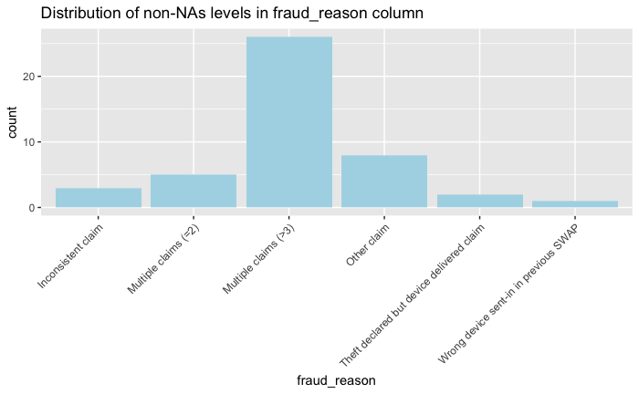

```r
fraud$fraud_reason = as.character(fraud$fraud_reason)
fraud$fraud_reason[fraud$fraud_reason == "Declared theft of delivered device (stolen out of post box)"] = "Theft declared but device delivered claim"
fraud$fraud_reason[fraud$fraud_reason == "Inconsistent or not plausible claim declaration"] = "Inconsistent claim"
fraud$fraud_reason[fraud$fraud_reason == "Multiple claims (2nd theft claim)"] = "Multiple claims (=2)"
fraud$fraud_reason[fraud$fraud_reason == "Multiple claims (more than 3 claims in 2 years)"] = "Multiple claims (>3)"
fraud$fraud_reason[fraud$fraud_reason == "Multiple claims (more than 3 claims in 2 years)"] = "Wrong device claim"
fraud$fraud_reason[fraud$fraud_reason == "Other"] = "Other claim"
ggplot(fraud, aes(x = fraud_reason)) + geom_bar(fill = "lightblue") + theme(axis.text.x = element_text(size  = 9, angle = 45, hjust = 1, vjust = 1)) + ggtitle("Distribution of non-NAs levels in fraud_reason column")
```

Distribution of the non-NAs levels in claim_rejection_reason column.

```r
length(levels(rejected$claim_rejection_reason))
```

```
[1] 24
```

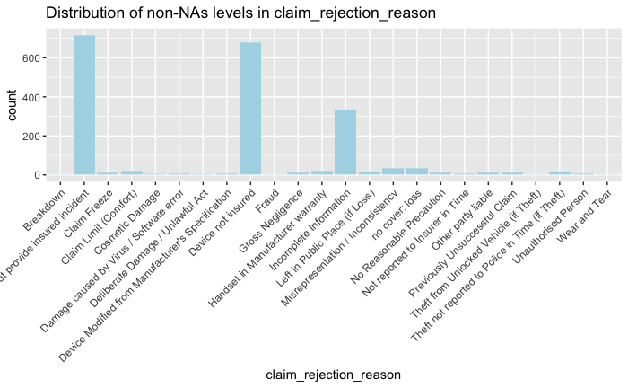

```r
ggplot(rejected, aes(x = claim_rejection_reason)) + geom_bar(fill = "lightblue") + theme(axis.text.x = element_text(size  = 9, angle = 45, hjust = 1, vjust = 1)) + ggtitle("Distribution of non-NAs levels in claim_rejection_reason")
```

Distribution of levels in product_name column.

```r
levels(claims$product_name)
```

```
 [1] "Cannot provide insured incident"  "Device not insured"               "DROPPED_FROM_PERSON"              "Handset in Manufacturer warranty"
 [5] "Incomplete Information"           "no cover: loss"                   "Sunrise call protect"             "Sunrise protect (legacy)"
 [9] "Sunrise protect basic"            "Sunrise protect Basic (old)"      "Sunrise protect comfort"          "Sunrise protect Comfort (old)"
[13] "Sunrise protect premium"          "Sunrise protect Premium (old)"    "Sunrise smart protect 1500"       "Sunrise smart protect 1500 (old)"
[17] "Sunrise smart protect 400"        "Sunrise smart protect 600"
```

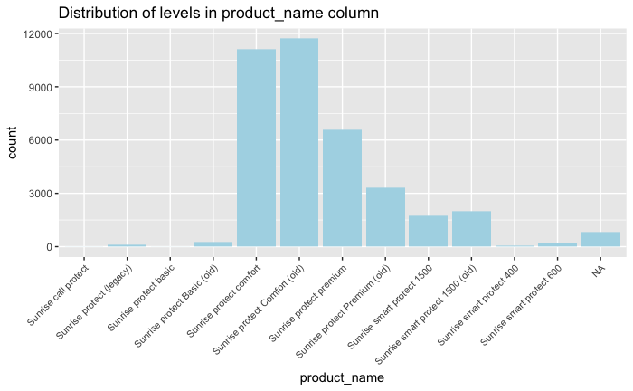

```r
claims$product_name = gsub("Cannot provide insured incident",NA,claims$product_name)
claims$product_name = gsub("Handset in Manufacturer warranty",NA,claims$product_name)
claims$product_name = gsub("Device not insured",NA,claims$product_name)
claims$product_name = gsub("DROPPED_FROM_PERSON",NA,claims$product_name)
claims$product_name = gsub("no cover: loss",NA,claims$product_name)
claims$product_name = gsub("Incomplete Information",NA,claims$product_name)
ggplot(claims, aes(x = product_name)) + geom_bar(fill = "lightblue") + theme(axis.text.x = element_text(size  = 8, angle = 45, hjust = 1, vjust = 1)) + ggtitle("Distribution of levels in product_name column")
```

Distribution of levels in contract_status column.

```r
length(levels(claims$contract_status))
```

```
[1] 2
```

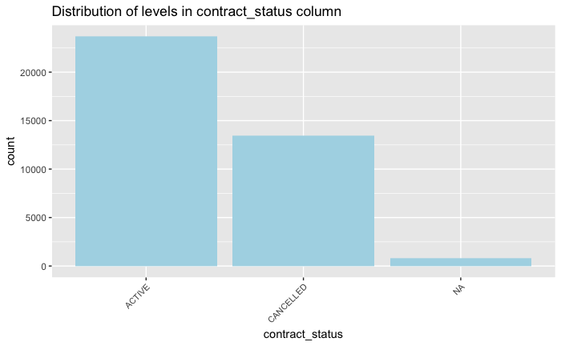

```r
ggplot(claims, aes(x = contract_status)) + geom_bar(fill = "lightblue") + theme(axis.text.x = element_text(size  = 8, angle = 45, hjust = 1, vjust = 1)) + ggtitle("Distribution of levels in contract_status column")
```

Distribution of levels in claim_type column.

```r
length(levels(claims$claim_type))
```

```
[1] 3
```

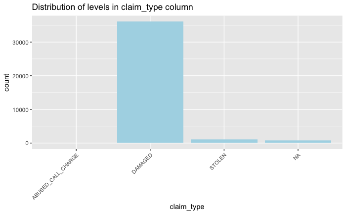

```r
ggplot(claims, aes(x = claim_type)) + geom_bar(fill = "lightblue") + theme(axis.text.x = element_text(size  = 8, angle = 45, hjust = 1, vjust = 1)) + ggtitle("Distribution of levels in claim_type column")
```

Distribution of levels in status_before_closed column.

```r
length(levels(claims$status_before_closed))
```

```
[1] 4
```

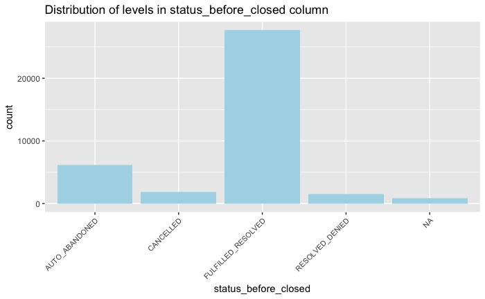

```r
ggplot(claims, aes(x = status_before_closed)) + geom_bar(fill = "lightblue") + theme(axis.text.x = element_text(size  = 8, angle = 45, hjust = 1, vjust = 1)) + ggtitle("Distribution of levels in status_before_closed column")
```

Distribution of levels in claim_caused_by column.

```r
length(levels(claims$claim_caused_by))
```

```
[1] 2
```

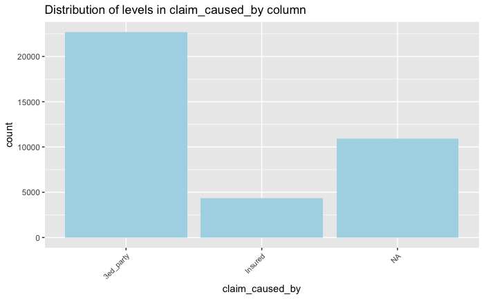

```r
ggplot(claims, aes(x = claim_caused_by)) + geom_bar(fill = "lightblue") + theme(axis.text.x = element_text(size  = 8, angle = 45, hjust = 1, vjust = 1)) + ggtitle("Distribution of levels in claim_caused_by column")
```

Distribution of levels in Pictures.of.the.damaged.device.required. column.

```r
length(levels(claims$Pictures.of.the.damaged.device.required.))
```

```
[1] 2
```

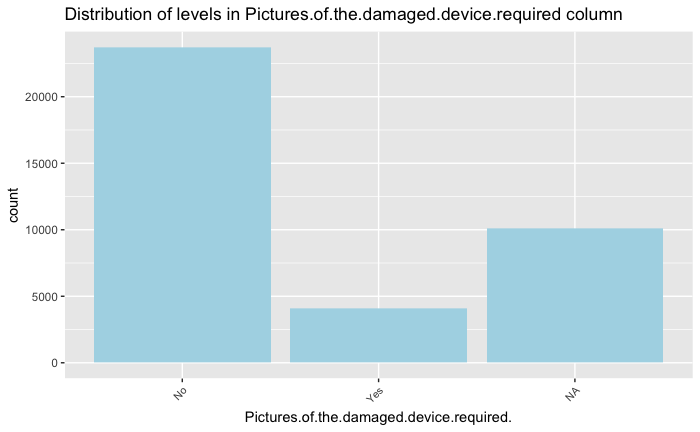

```r
ggplot(claims, aes(x = Pictures.of.the.damaged.device.required.)) + geom_bar(fill = "lightblue") + theme(axis.text.x = element_text(size  = 8, angle = 45, hjust = 1, vjust = 1)) + ggtitle("Distribution of levels in Pictures.of.the.damaged.device.required column")
```

Distribution of levels in Poof.of.purchase.required. column.

```r
length(levels(claims$Proof.of.purchase.required.))
```

```
[1] 2
```

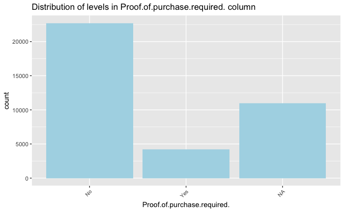

```r
ggplot(claims, aes(x = Proof.of.purchase.required.)) + geom_bar(fill = "lightblue") + theme(axis.text.x = element_text(size  = 8, angle = 45, hjust = 1, vjust = 1)) + ggtitle("Distribution of levels in Proof.of.purchase.required. column")
```

Distribution of levels in Was.a.Police.report.filed. column.

```r
length(levels(claims$Was.a.Police.report.filed.))
```

```
[1] 2
```

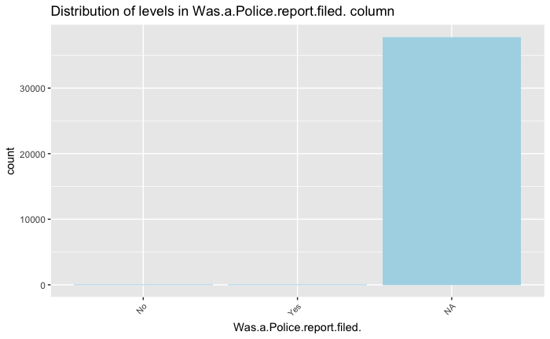

```r
ggplot(claims, aes(x = Was.a.Police.report.filed.)) + geom_bar(fill = "lightblue") + theme(axis.text.x = element_text(size  = 8, angle = 45, hjust = 1, vjust = 1)) + ggtitle("Distribution of levels in Was.a.Police.report.filed. column")
```

Distribution of levels in settlement_reason column.

```r
length(levels(claims$settlement_reason))
```

```
[1] 13
```

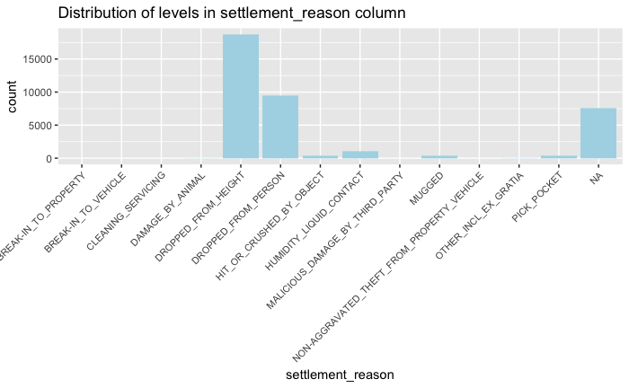

```r
ggplot(claims, aes(x = settlement_reason)) + geom_bar(fill = "lightblue") + theme(axis.text.x = element_text(size  = 8, angle = 45, hjust = 1, vjust = 1)) + ggtitle("Distribution of levels in settlement_reason column")
```

Distribution of levels in customer_language column.

```r
length(levels(claims$customer_language))
```

```
[1] 7
```

```r
levels(claims$customer_language)
```

```
[1] "3ed_party" "de"        "en"        "fr"        "Insured"   "it"        "m"
```

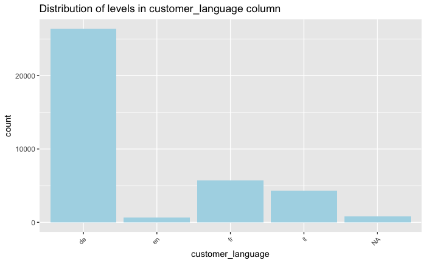

```r
claims$customer_language = gsub("3ed_party",NA,claims$customer_language)
claims$customer_language = gsub("Insured",NA,claims$customer_language)
claims$customer_language = gsub("m",NA,claims$customer_language)
ggplot(claims, aes(x = customer_language)) + geom_bar(fill = "lightblue") + theme(axis.text.x = element_text(size  = 8, angle = 45, hjust = 1, vjust = 1)) + ggtitle("Distribution of levels in customer_language column")
```

Distribution of levels in device_type column.

```r
levels(claims$device_type)
```

```
[1] "Mobiltelefon/Smartphone/PDA" "Sonstige"
```

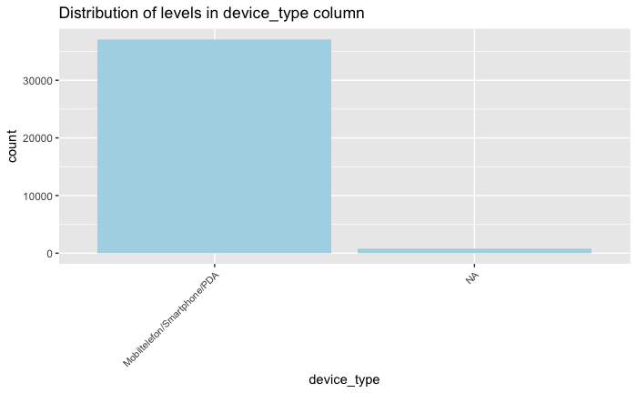

```r
claims$device_type = gsub("Sonstige",NA,claims$device_type)
ggplot(claims, aes(x = device_type)) + geom_bar(fill = "lightblue") + theme(axis.text.x = element_text(size  = 8, angle = 45, hjust = 1, vjust = 1)) + ggtitle("Distribution of levels in device_type column")
```

Distribution of levels in claim_created_by column.

```r
length(levels(claims$claim_created_by))
```

```
[1] 2
```

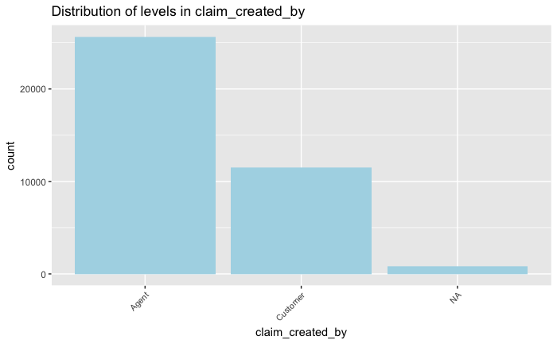

```r
ggplot(claims, aes(x = claim_created_by)) + geom_bar(fill = "lightblue") + theme(axis.text.x = element_text(size  = 8, angle = 45, hjust = 1, vjust = 1)) + ggtitle("Distribution of levels in claim_created_by")
```

Distribution of levels in claim_caused_by column.

```r
length(levels(claims$claim_caused_by))
```

```
[1] 2
```

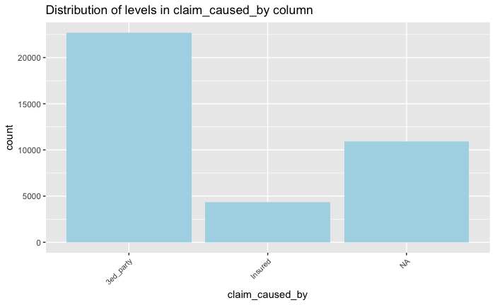

```r
ggplot(claims, aes(x = claim_caused_by)) + geom_bar(fill = "lightblue") + theme(axis.text.x = element_text(size  = 8, angle = 45, hjust = 1, vjust = 1)) + ggtitle("Distribution of levels in claim_caused_by column")
```

Distribution of values in claim_device_memory column.

```r
length(unique(claims$claim_device_memory))
```

```
[1] 86
```

```r
length(is.na(claims$claim_device_memory))
```

```
[1] 37938
```

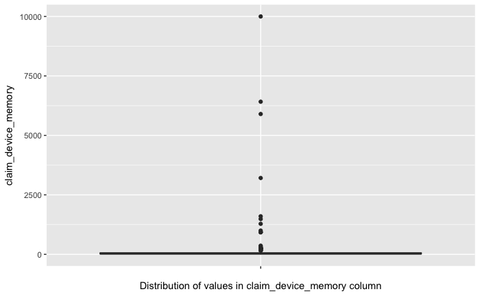

```r
claims_nonnas_memory = claims %>% filter(!is.na(claim_device_memory))
claims_nonnas_memory %>% ggplot(aes(x = "", y = claim_device_memory)) + geom_boxplot() + xlab("Distribution of values in claim_device_memory column")
```

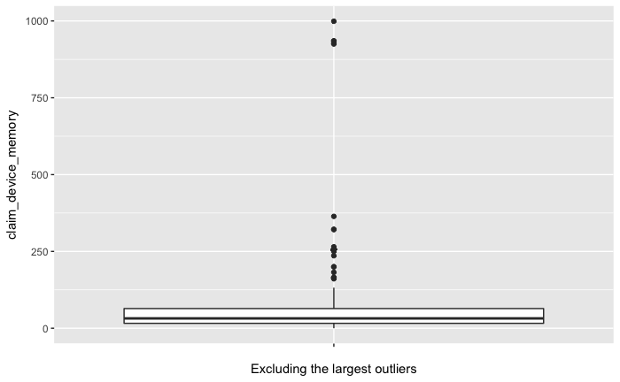

```r
# Discarding the largest outliers from data
claims_little_memory = claims %>% filter(claim_device_memory<1000)
# Box plot of claim_device_memory using the reduced dataset
claims_little_memory %>% ggplot(aes(x = "", y = claim_device_memory)) + geom_boxplot() + xlab("Excluding the largest outliers")
```

Distribution of levels in make column.

```r
length(levels(claims$make))
```

```
[1] 22
```

```r
claims$make = gsub("iPhone","Apple",claims$make)
claims$make = gsub("HUAWEI","Huawei",claims$make)
claims$make = gsub("Local Brand","Local",claims$make)
claims$make = gsub("sony","Sony",claims$make)
claims$make = gsub("XPERIA","Sony",claims$make)
claims$make = gsub("Galaxy","Samsung",claims$make)
claims$make = gsub("I-surance","Insurance",claims$make)
claims$make = gsub("ToBeFilled",NA,claims$make)
claims$make = gsub("DUMMY",NA,claims$make)
claims$make = factor(claims$make)
length(levels(claims$make))
```

```
[1] 14
```

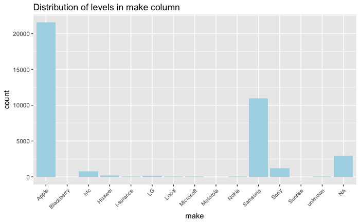

```r
ggplot(claims, aes(x = make)) + geom_bar(fill = "lightblue") + theme(axis.text.x = element_text(size  = 8, angle = 45, hjust = 1, vjust = 1)) + ggtitle("Distribution of levels in make column")
```

Distribution of levels in claim_device_make column before replacements

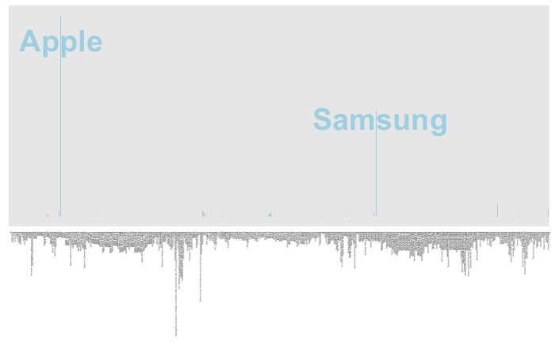

```r
tt <- table(claims$claim_device_make)
ggplot(claims, aes(x = claim_device_make)) + geom_bar(fill = "lightblue") + theme(axis.text.x = element_text(size  = 2, angle = 90, hjust = 1, vjust = 1))  + rremove("y.text") + rremove("ylab") + rremove("xlab") + rremove("grid") + rremove("y.ticks") + rremove("x.ticks") + annotate("text", x = c(50,350), y = c(18000,10000), label = c("Apple", "Samsung") , color="lightblue", size=10 , fontface="bold")
```

Synthesis of the recurring patterns in claim_device_make column using Fuzzy Matching.

We will use the agrep function (base package) that uses in turn the Levenshtein distance to measure the distance between two strings.  
The Levenshtein distance between two words is the minimum number of single-character edits (insertions, deletions or substitutions) required to change one word into the other.  
It is zero if and only if the strings are equal.  
If we pass to agrep as first argument a string “pattern” and as second argument a vector of strings x, the function answers to this question: can I transform pattern into a sub string of an element of x? So it is searching for matches “within” elements of x.

```r
length(unique(agrep("Apple", claims$claim_device_make, ignore.case = TRUE, value = TRUE,max.distance = 2)))*100/length(unique(claims$claim_device_make))
```

```
[1] 25.3937
```

Strings in claim_device_make that fuzzy match (Levenshtein distance=2) -Apple-

```r
unique(agrep("Apple", claims$claim_device_make, ignore.case = TRUE, value = TRUE,max.distance = 2))
```

```
  [1] "Apple"                                              "Apple iPhone 5s"                                    "Appel"
  [4] "apple"                                              "APPLE"                                              "Apel"
  [7] "Apple Iphone"                                       "apple iphone"                                       "Apple I Phone"
 [10] "appel"                                              "Aepple"                                             "Apple iPhone"
 [13] "Apple Iphone 6"                                     "Aple"                                               "Apple IPhone"
 [16] "Appleq"                                             "Apple I phone 5s"                                   "appei"
 [19] "Apple "                                             "Apple I-Phone"                                      "Apple iPhone 6"
 [22] "Apple iphone 6"                                     "Aplle iPhone"                                       "IPHONE 6 apple"
 [25] "Apple IPhone 5c 16GB"                               "Apple iPhone 6s"                                    "Aplle"
 [28] "Apple iphone"                                       "apple I Phone 6 Plus"                               "Apple iPhone 6s PLUS"
 [31] "Apple iPhone 6 64GB"                                "aple"                                               "apple iphone 5s32gb"
 [34] "apple iPhone 5s"                                    "Apple iPhone 5s 16GB"                               "aplle"
 [37] "Apple iPhone 6s 64GB"                               "Appele"                                             "Apple Inc."
 [40] "Apple iPhone 6 16GB"                                "APPLE PHONE"                                        "aepple"
 [43] "apple iPhone"                                       "Apple iPhone 6s Plus"                               "Apple AG"
```

[output cut: 28 more lines]

Percentage of strings in claim_device_make that fuzzy match (Levenshtein distance=2) -Yotaphone-

```r
length(unique(agrep("Yotaphone", claims$claim_device_make, ignore.case = TRUE, value = TRUE,max.distance = 2)))*100/length(unique(claims$claim_device_make))
```

```
[1] 0.1968504
```

Strings in claim_device_make that fuzzy match (Levenshtein distance=2) -Yotaphone-

```r
unique(agrep("Yotaphone",claims$claim_device_make, ignore.case = TRUE, value = TRUE,max.distance = 2))
```

```
[1] "Yotaphone"
```

Percentage of strings in claim_device_make that fuzzy match (Levenshtein distance=2) -iPhone-

```r
length(unique(agrep("iPhone", claims$claim_device_make, ignore.case = TRUE, value = TRUE,max.distance = 2)))*100/length(unique(claims$claim_device_make))
```

```
[1] 33.46457
```

Strings in claim_device_make that fuzzy match (Levenshtein distance=2) -iPhone-

```r
unique(agrep("iPhone", claims$claim_device_make, ignore.case = TRUE, value = TRUE,max.distance = 2))
```

```
  [1] "Apple iPhone 5s"
  [2] "i Phone Mac"
  [3] "Iphone"
  [4] "iphone"
  [5] "iPhone"
  [6] "IPhone 6"
  [7] "IPHONE"
  [8] "Apple Iphone"
  [9] "apple iphone"
 [10] "Apple I Phone"
 [11] "I-phone"
 [12] "I phone"
 [13] "I Phone"
 [14] "Apple iPhone"
 [15] "Iphone "
```

[output cut: 155 more lines]

Percentage of strings in claim_device_make that fuzzy match (Levenshtein distance=3) -Samsung-

```r
length(unique(agrep("Samsung", claims$claim_device_make, ignore.case = TRUE, value = TRUE,max.distance = 3)))*100/length(unique(claims$claim_device_make))
```

```
[1] 24.6063
```

Strings in claim_device_make that fuzzy match (Levenshtein distance=3) -Samsung-

```r
unique(agrep("Samsung", claims$claim_device_make, ignore.case = TRUE, value = TRUE,max.distance = 3))
```

```
  [1] "Samsung"                                  "SAMSUNG"                                  "Samsung galaxy s4"
  [4] "samsung"                                  "Samsung Galaxy S/"                        "Samsung SM-G935"
  [7] "Sasug"                                    "Samung"                                   "Samsung Galaxy S III"
 [10] "Samsung Galaxy"                           "Samsung G928"                             "Samsung SM-G920"
 [13] "Samsung Galaxy s7 edge"                   "Samsung SM-G900"                          "samsung sm-n915f"
 [16] "Sumsung"                                  "Samsung (schwarz"                         "Samsund"
 [19] "sumsung  Galaxy S7 edge"                  "samsung galaxy s5"                        "Samsung SM-G930"
 [22] "samsumg"                                  "Samgsung"                                 "Samung Galaxy"
 [25] "Samsung Galaxy S5"                        "Samsung S5"                               "Sansung"
 [28] "Samsung s6  edge"                         "Sasmung"                                  "Samsung "
 [31] "SamsungSM-A500"                           "SAMSUNG GALAXY S7 EDGE"                   "Samsug"
 [34] "Samsung galaxy s6"                        "Samsung Galaxy S4"                        "Samsung sm-g920"
 [37] "Samsng"                                   "Samsung SM-G935 32GB Galaxy S7 edge"      "Samsumg"
 [40] "SAmsung SM-G925"                          "samsung sm-A510"                          "Samsung SM-G955."
 [43] "Samsung SM-G850"                          "Samsung Galaxy S7"                        "Samsung Galaxy 7"
```

[output cut: 27 more lines]

Percentage of strings in claim_device_make that fuzzy match (Levenshtein distance=.1) -Sony-

```r
length(unique(agrep("Sony", claims$claim_device_make, ignore.case = TRUE, value = TRUE)))*100/length(unique(claims$claim_device_make))
```

```
[1] 2.755906
```

Strings in claim_device_make that fuzzy match (Levenshtein distance=.1) -Sony-

```r
unique(agrep("Sony", claims$claim_device_make, ignore.case = TRUE, value = TRUE))
```

```
 [1] "Sony"                   "sony"                   "SONY"                   "Sony Ericson"           "Sony Xperia"            "sony experia"
 [7] "Sony Xperia Z3 Compact" "sonx"                   "Sony Xperia Z3"         "sony xperia"            "sony Ericson"           "sony Xperia"
[13] "Sony xperia z3 compact" "Sony Experia"
```

Percentage of strings in claim_device_make that fuzzy match (Levenshtein distance=1) -htc-

```r
length(unique(agrep("htc", claims$claim_device_make, ignore.case = TRUE, value = TRUE,max.distance = 1)))*100/length(unique(claims$claim_device_make))
```

```
[1] 4.133858
```

Strings in claim_device_make that fuzzy match (Levenshtein distance=1) -htc-

```r
unique(agrep("htc", claims$claim_device_make, ignore.case = TRUE, value = TRUE,max.distance = 1))
```

```
 [1] "HTC"                                            "htc"                                            "Htc"
 [4] "HTC 1"                                          "HTC One"                                        "HTC One A9"
 [7] "htc 601 N"                                      "htc1"                                           "htc M7"
[10] "HTC ONE"                                        "HCT"                                            "steht beim Versicherungsvertrag"
[13] "HTC One M8 16GB"                                "HTC 10"                                         "HTC ONE M9"
[16] "HTC1"                                           "Am bode runtergefahren, displau tut nicht mehr" "weis nicht"
[19] "weiss nicht"                                    "HTC (Taiwan)"                                   "htcone"
```

Percentage of strings in claim_device_make that fuzzy match (Levenshtein distance=1.5) -Huawei-

```r
length(unique(agrep("Huawei", claims$claim_device_make, ignore.case = TRUE, value = TRUE,max.distance = 1.5)))*100/length(unique(claims$claim_device_make))
```

```
[1] 2.165354
```

Strings in claim_device_make that fuzzy match (Levenshtein distance=1.5) -Huawei-

```r
unique(agrep("Huawei", claims$claim_device_make, ignore.case = TRUE, value = TRUE,max.distance = 1.5))
```

```
 [1] "Huawei"         "huawei"         "HUAWEI"         "Huaweii"        "Huaway"         "Huawei P9"      "Huawai"         "Huawei P8"      "schweiz"
[10] "Huawei5"        "Huawei P9 32GB"
```

Percentage of strings in claim_device_make that fuzzy match (Levenshtein distance=1) -Blackberry-

```r
length(unique(agrep("Blackberry", claims$claim_device_make, ignore.case = TRUE, value = TRUE,max.distance = 1)))*100/length(unique(claims$claim_device_make))
```

```
[1] 0.3937008
```

Strings in claim_device_make that fuzzy match (Levenshtein distance=1) -Blackberry-

```r
unique(agrep("Blackberry", claims$claim_device_make, ignore.case = TRUE, value = TRUE,max.distance = 1))
```

```
[1] "Blackberry" "BlackBerry"
```

Percentage of strings in claim_device_make that fuzzy match (at Levenshtein distance=1) -I-surance-

```r
length(unique(agrep("I-surance", claims$claim_device_make, ignore.case = TRUE, value = TRUE,max.distance = 1)))*100/length(unique(claims$claim_device_make))
```

```
[1] 0.1968504
```

Strings in claim_device_make that fuzzy match (at Levenshtein distance=1) -I-surance-

```r
unique(agrep("I-surance", claims$claim_device_make, ignore.case = TRUE, value = TRUE,max.distance = 1))
```

```
[1] "i-surance"
```

Percentage of strings in claim_device_make that fuzzy match (at Levenshtein distance =0) -LG-

```r
length(unique(agrep("LG", claims$claim_device_make, ignore.case = TRUE, value = TRUE,max.distance = 0)))*100/length(unique(claims$claim_device_make))
```

```
[1] 0.7874016
```

Strings in claim_device_make that fuzzy match (at Levenshtein distance =0) -LG-

```r
unique(agrep("LG", claims$claim_device_make, ignore.case = TRUE, value = TRUE,max.distance = 0))
```

```
[1] "LG"    "Lg"    "lg"    "LG G4"
```

```r
length(unique(agrep("Local", claims$claim_device_make, ignore.case = TRUE, value = TRUE,max.distance = 2)))*100/length(unique(claims$claim_device_make))
```

```
[1] 2.559055
```

Strings in claim_device_make that fuzzy match (at Levenshtein distance =1) -Local-

```r
unique(agrep("Local", claims$claim_device_make, ignore.case = TRUE, value = TRUE,max.distance = 1))
```

```
[1] "Local Brand"
```

Percentage of strings in claim_device_make that fuzzy match (at Levenshtein distance =4) -Microsoft-

```r
length(unique(agrep("Microsoft", claims$claim_device_make, ignore.case = TRUE, value = TRUE,max.distance = 4)))*100/length(unique(claims$claim_device_make))
```

```
[1] 0.5905512
```

Strings in claim_device_make that fuzzy match (at Levenshtein distance =4) -Microsoft-

```r
unique(agrep("Microsoft", claims$claim_device_make, ignore.case = TRUE, value = TRUE,max.distance = 4))
```

```
[1] "Microsoft" "microsoft" "Micorsoft"
```

Percentage of strings in claim_device_make that fuzzy match (at Levenshtein distance =3) -Motorola-

```r
length(unique(agrep("Motorola", claims$claim_device_make, ignore.case = TRUE, value = TRUE,max.distance = 3)))*100/length(unique(claims$claim_device_make))
```

```
[1] 0.1968504
```

Strings in claim_device_make that fuzzy match (at Levenshtein distance =3) -Motorola-

```r
unique(agrep("Motorola", claims$claim_device_make, ignore.case = TRUE, value = TRUE,max.distance = 3))
```

```
[1] "Motorola"
```

Percentage of strings in claim_device_make that fuzzy match (at Levenshtein distance =1) -Nokia-

```r
length(unique(agrep("Nokia", claims$claim_device_make, ignore.case = TRUE, value = TRUE,max.distance = 1)))*100/length(unique(claims$claim_device_make))
```

```
[1] 0.3937008
```

Strings in claim_device_make that fuzzy match (at Levenshtein distance =1) -Nokia-

```r
unique(agrep("Nokia", claims$claim_device_make, ignore.case = TRUE, value = TRUE,max.distance = 1))
```

```
[1] "Nokia" "nokia"
```

Percentage of strings in claim_device_make that fuzzy match (at Levenshtein distance =2) -Sunrise-

```r
length(unique(agrep("Sunrise", claims$claim_device_make, ignore.case = TRUE, value = TRUE,max.distance = 2)))*100/length(unique(claims$claim_device_make))
```

```
[1] 3.149606
```

Strings in claim_device_make that fuzzy match (at Levenshtein distance =2) -Sunrise-

```r
unique(agrep("Sunrise", claims$claim_device_make, ignore.case = TRUE, value = TRUE,max.distance = 2))
```

```
 [1] "Sunrise"                                       "Sunrice"                                       "SUNRISE"
 [4] "sunrise"                                       "Sunrise shop"                                  "Sunise"
 [7] "Sunsrise"                                      "Sunrise Communications AG"                     "sunrise protect"
[10] "Apple / Sunrise"                               "Sunrise Center Winterthur Untertor, Untertor7" "sunrise center Basel Greifengasse 17"
[13] "Sunrise Center Stücki"                         "Sunrice protect"                               "Sunrise Communication AG"
[16] "Sunrise Airport"
```

Percentage of elements of the column claim_device_make that are represented by the values previously chosen to apply the agrep function

```r
length(unique(agrep("Apple", claims$claim_device_make, ignore.case = TRUE, value = TRUE,max.distance = 2)))*100/length(unique(claims$claim_device_make))+
length(unique(agrep("Yotaphone",claims$claim_device_make, ignore.case = TRUE, value = TRUE,max.distance = 2)))*100/length(unique(claims$claim_device_make))+
length(unique(agrep("iPhone", claims$claim_device_make, ignore.case = TRUE, value = TRUE,max.distance = 2)))*100/length(unique(claims$claim_device_make))+
length(unique(agrep("Samsung", claims$claim_device_make, ignore.case = TRUE, value = TRUE,max.distance = 3)))*100/length(unique(claims$claim_device_make))+
length(unique(agrep("Sony", claims$claim_device_make, ignore.case = TRUE, value = TRUE)))*100/length(unique(claims$claim_device_make))+
length(unique(agrep("htc", claims$claim_device_make, ignore.case = TRUE, value = TRUE,max.distance = 1)))*100/length(unique(claims$claim_device_make))+
length(unique(agrep("Huawei", claims$claim_device_make, ignore.case = TRUE, value = TRUE,max.distance = 1.5)))*100/length(unique(claims$claim_device_make))+
length(unique(agrep("Blackberry", claims$claim_device_make, ignore.case = TRUE, value = TRUE,max.distance = 1)))*100/length(unique(claims$claim_device_make))+
length(unique(agrep("I-surance", claims$claim_device_make, ignore.case = TRUE, value = TRUE,max.distance = 1)))*100/length(unique(claims$claim_device_make))+
length(unique(agrep("LG", claims$claim_device_make, ignore.case = TRUE, value = TRUE,max.distance = 0)))*100/length(unique(claims$claim_device_make))+
length(unique(agrep("Local", claims$claim_device_make, ignore.case = TRUE, value = TRUE,max.distance = 1)))*100/length(unique(claims$claim_device_make))+
length(unique(agrep("Microsoft", claims$claim_device_make, ignore.case = TRUE, value = TRUE,max.distance = 4)))*100/length(unique(claims$claim_device_make))+
length(unique(agrep("Motorola", claims$claim_device_make, ignore.case = TRUE, value = TRUE,max.distance = 3)))*100/length(unique(claims$claim_device_make))+
length(unique(agrep("Nokia", claims$claim_device_make, ignore.case = TRUE, value = TRUE,max.distance = 1)))*100/length(unique(claims$claim_device_make))+
length(unique(agrep("Sunrise", claims$claim_device_make, ignore.case = TRUE, value = TRUE,max.distance = 2)))*100/length(unique(claims$claim_device_make))
```

```
[1] 98.62205
```

Replacing the fuzzy matching found with agrep with the corresponding “synthetic form”

```r
claims$claim_device_make = gsub(pattern="\\(", replacement="",claims$claim_device_make) # removing left parentheses since they were giving errors with gsub
claims$claim_device_make = gsub(pattern=")", replacement="",claims$claim_device_make)
apple = unique(agrep("Apple", claims$claim_device_make, ignore.case = TRUE, value = TRUE,max.dist=2))
for (i in 1:length(apple)){
  claims$claim_device_make = gsub(apple[i],"Apple",claims$claim_device_make)
}
yota = unique(agrep("Yotaphone",claims$claim_device_make, ignore.case = TRUE, value = TRUE,max.distance = 2))
for (i in 1:length(yota)){
  claims$claim_device_make = gsub(yota[i],"Yotaphone",claims$claim_device_make)
}
iphone = unique(agrep("iPhone", claims$claim_device_make, ignore.case = TRUE, value = TRUE,max.distance = 2))
for (i in 1:length(iphone)){
  claims$claim_device_make = gsub(iphone[i],"Apple",claims$claim_device_make)
}
sony = unique(agrep("Sony", claims$claim_device_make, ignore.case = TRUE, value = TRUE))
for (i in 1:length(sony)){
  claims$claim_device_make = gsub(sony[i],"Sony",claims$claim_device_make)
}
htc = unique(agrep("htc", claims$claim_device_make, ignore.case = TRUE, value = TRUE,max.distance = 1))
for (i in 1:length(htc)){
  claims$claim_device_make = gsub(htc[i],"Htc",claims$claim_device_make)
}
huawei = unique(agrep("Huawei", claims$claim_device_make, ignore.case = TRUE, value = TRUE,max.distance = 1.5))
for (i in 1:length(huawei)){
  claims$claim_device_make = gsub(huawei[i],"Huawei",claims$claim_device_make)
}
blackberry = unique(agrep("Blackberry", claims$claim_device_make, ignore.case = TRUE, value = TRUE,max.distance = 1))
for (i in 1:length(blackberry)){
  claims$claim_device_make = gsub(blackberry[i],"Blackberry",claims$claim_device_make)
}
insurance = unique(agrep("I-surance", claims$claim_device_make, ignore.case = TRUE, value = TRUE,max.distance = 1))
for (i in 1:length(insurance)){
  claims$claim_device_make = gsub(insurance[i],"Insurance",claims$claim_device_make)
}
lg = unique(agrep("LG", claims$claim_device_make, ignore.case = TRUE, value = TRUE,max.distance = 0))
for (i in 1:length(lg)){
  claims$claim_device_make = gsub(lg[i],"LG",claims$claim_device_make)
}
local = unique(agrep("Local", claims$claim_device_make, ignore.case = TRUE, value = TRUE,max.distance = 1))
for (i in 1:length(local)){
  claims$claim_device_make = gsub(local[i],"Local",claims$claim_device_make)
}
microsoft = unique(agrep("Microsoft", claims$claim_device_make, ignore.case = TRUE, value = TRUE,max.distance = 4))
for (i in 1:length(microsoft)){
  claims$claim_device_make = gsub(microsoft[i],"Microsoft",claims$claim_device_make)
}
motorola = unique(agrep("Motorola", claims$claim_device_make, ignore.case = TRUE, value = TRUE,max.distance = 3))
for (i in 1:length(motorola)){
  claims$claim_device_make = gsub(motorola[i],"Motorola",claims$claim_device_make)
}
sunrise = unique(agrep("Sunrise", claims$claim_device_make, ignore.case = TRUE, value = TRUE,max.distance = 2))
for (i in 1:length(sunrise)){
  claims$claim_device_make = gsub(sunrise[i],"Sunrise",claims$claim_device_make)
}
nokia = unique(agrep("Nokia", claims$claim_device_make, ignore.case = TRUE, value = TRUE,max.distance = 1))
for (i in 1:length(nokia)){
  claims$claim_device_make = gsub(nokia[i],"Nokia",claims$claim_device_make)
}
samsung = unique(agrep("Samsung", claims$claim_device_make, ignore.case = TRUE, value = TRUE,max.distance = 3))
for (i in 1:length(samsung)){
  claims$claim_device_make = gsub(samsung[i],"Samsung",claims$claim_device_make,fixed=TRUE)
}
```

Replacing the unmatched levels with NA

```r
`%nin%` = Negate(`%in%`)
for (i in 1:length(claims$claim_device_make)){
    if(claims$claim_device_make[i]%nin%c("Apple","Yotaphone","Samsung","Sony","htc","Huawei","Blackberry","Insurance","LG","Local","Microsoft","Motorola","Sunrise","Nokia"))
        claims$claim_device_make[i] = NA
}
```

Distribution of levels in claim_device_make column after replacements

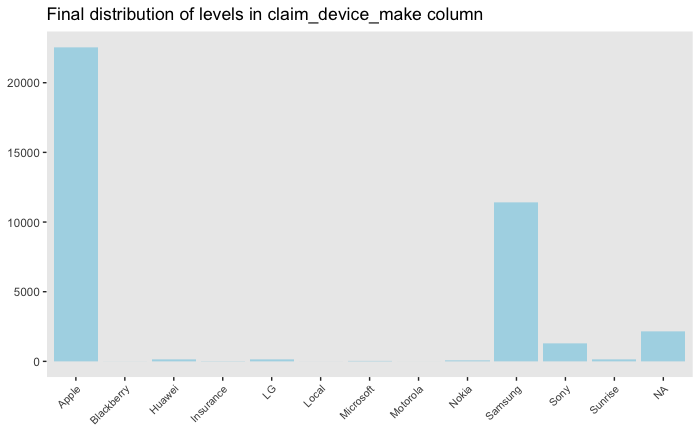

```r
ggplot(claims, aes(x = claim_device_make)) + geom_bar(fill = "lightblue") + theme(axis.text.x = element_text(size  = 8, angle = 45, hjust = 1, vjust = 1)) + ggtitle("Final distribution of levels in claim_device_make column") + rremove("ylab") + rremove("xlab") + rremove("grid")
```

Number of unique elements of model and of claim_device_model

```r
length(unique(claims$model))
```

```
[1] 485
```

```r
length(unique(claims$claim_device_model))
```

```
[1] 3147
```

Synthesis of recurring patterns in model column using fuzzy matching.

```r
claims$model = gsub("[()]", "", claims$model)
```

Percentage of strings in model that fuzzy match (Levenshtein distance=3) -iPhone-

```r
length(unique(agrep("iPhone", claims$model, ignore.case = FALSE, value = TRUE,max.distance = 3)))*100/length(unique(claims$model))
```

```
[1] 31.31524
```

Strings in model that fuzzy match (Levenshtein distance=3) -iPhone-

```r
unique(agrep("iPhone", claims$model, ignore.case = FALSE, value = TRUE,max.distance = 3))
```

```
  [1] "iPhone 5c"                                       "iPhone 5S"                                       "iPhone 6"
  [4] "iPhone 5"                                        "iPhone 6 Plus"                                   "iPhone 4S"
  [7] "iPhone 5s 32GB"                                  "iPhone 6 Plus 64GB"                              "iPhone 6 16GB"
 [10] "iPhone 6 64GB"                                   "iPhone 6 128GB"                                  "iPhone 5s 16GB"
 [13] "iPhone 6s Plus 64GB"                             "iPhone 6 Plus 16GB"                              "iPhone 6s Plus 16GB"
 [16] "iPhone 6s 16GB"                                  "iPhone 6s 64GB"                                  "Xperia? Z3 & PlayStationÂ® 4"
 [19] "iPhone 6 Plus 128GB"                             "iPhone 4S 8GB"                                   "iPhone 6 64GB Grey"
 [22] "iPhone 5c 16GB"                                  "iPhone 6s 128GB"                                 "iPhone 6S"
 [25] "iPhone 6s 128GB Rose"                            "iPhone 6s Plus 128GB"                            "iPhone 6S Plus"
 [28] "iPhone 6s 16GB Grey"                             "iPhone 6 16GB Grey"                              "iPhone 7 128GB"
 [31] "iPhone 7 Plus 128GB"                             "iPhone 6s Plus 64GB Silver"                      "iPhone 7 32GB"
 [34] "iPhone 6s 64GB Rose"                             "iPhone 7 256GB"                                  "iPhone 7 Plus 256GB"
 [37] "iPhone 7 Plus"                                   "iPhone 7 Plus 32GB"                              "iPhone 6 16GB Silver"
 [40] "iPhone 6 64GB Gold"                              "iPhone 4"                                        "iPhone SE"
 [43] "iPhone 6 Plus 64GB Gold"                         "iPhone 6 Plus 128GB Grey"                        "iPhone 6s 64GB Grey"
```

[output cut: 35 more lines]

Percentage of strings in model that fuzzy match (Levenshtein distance=2) -Xperia-

```r
length(unique(agrep("Xperia", claims$model, ignore.case = TRUE, value = TRUE,max.distance = 2)))*100/length(unique(claims$model))
```

```
[1] 8.977035
```

Strings in model that fuzzy match (Levenshtein distance=2) -Xperia-

```r
unique(agrep("Xperia", claims$model, ignore.case = TRUE, value = TRUE,max.distance = 2))
```

```
 [1] "Xperia Z1"                                       "Xperia Z3"                                       "Xperia Z3 Compact"
 [4] "Xperia Z1 Compact"                               "Xperia Z2"                                       "Xperia? Z3 & PlayStationÂ® 4"
 [7] "Xperia Z5"                                       "Xperia Z5 compact"                               "Xperia X Performance 32GB / F8131"
[10] "Xperia Z5 Premium"                               "Xperia Z5 Premium 32GB"                          "XPERIA Z3 BLACK / D6603"
[13] "Xperia Z"                                        "Xperia X compact 32GB"                           "Xperia X 32GB / F5121"
[16] "Xperia Z Ultra"                                  "Xperia Z3 & PlayStation 4"                       "Sony Xperia Z3 D6603, D6633"
[19] "Sony Xperia Z5 E6653 schwarz"                    "Xperia Z5 Compact"                               "Xperia? Z3 compact & PlayStationÂ® 4"
[22] "Xperia Z C6603"                                  "Xperia X"                                        "Xperia Z Ultra Black / C6833"
[25] "Xperia X F5121-PS10"                             "Xperia M2"                                       "XPERIA Z5 PREMIUM 32GB BLACK"
[28] "Xperia SP"                                       "Xperia SP C5303"                                 "Mobile Communications AB Sony D6503 - Xperia Z2"
[31] "XPERIA Z3 COMPACT BLACK / D5803"                 "XPERIA Z5 32GB BLACK / E6653"                    "Xperia Z3 Compact Black"
[34] "Sony Xperia Z5 Compact E5823"                    "Xperia X 32GB Black / F5121"                     "Xperia Z5 32GB Black / E6653"
[37] "Xperia XZ 32GB"                                  "Xperia M2 D2303"                                 "Xperia Z3 Black & PS4 500GB Black"
[40] "XPERIA Z1 BLACK / C6903"                         "Xperia Z3 compact & PlayStation 4"               "Xperia S"
[43] "Xperia Z1 C6903"
```

Percentage of strings in model that fuzzy match (Levenshtein distance=2) -Galaxy-

```r
length(unique(agrep("Galaxy", claims$model, ignore.case = TRUE, value = TRUE,max.distance = 2)))*100/length(unique(claims$model))
```

```
[1] 31.73278
```

Strings in model that fuzzy match (Levenshtein distance=2) -Galaxy-

```r
unique(agrep("Galaxy", claims$model, ignore.case = TRUE, value = TRUE,max.distance = 2))
```

```
  [1] "Galaxy S5 mini G800F"             "Galaxy S5 G900F"                  "Galaxy S4 I9505"                  "Galaxy Alpha G850F"
  [5] "SM-G900 16GB Galaxy S5"           "SM-G925 32GB Galaxy S6 Edge"      "SM-A500 Galaxy A5"                "SM-N910F Galaxy Note4"
  [9] "SM-G920 32GB Galaxy S6"           "N9005 32GB Galaxy Note3"          "I9505 16GB Galaxy S4"             "SM-G925 64GB Galaxy S6 Edge"
 [13] "SM-G920 64GB Galaxy S6"           "G928 32GB Galaxy S6 edge+"        "Galaxy A3 A310F 2016"             "Galaxy S6 Edge G925F"
 [17] "Galaxy S6 G920F"                  "Galaxy S6 Edge+ G928F"            "Galaxy S7 Edge G935F"             "SM-G930 32GB Galaxy S7"
 [21] "SM-G935 32GB Galaxy S7 edge"      "Galaxy Note 4 N910F"              "Galaxy S7 G930F"                  "Galaxy A5 A510F 2016"
 [25] "SM-G935 32GB Slv Galaxy S7 edge"  "Galaxy A5 A500FU"                 "Galaxy Note 7 N930F"              "Galaxy S4 mini I9195"
 [29] "SM-G955 64GB Galaxy S8+"          "SM-A520 32GB Galaxy A5 2017"      "SM-G950 64GB Galaxy S8"           "Galaxy S III i9300"
 [33] "Galaxy Note 3 N9005"              "SM-G800 Galaxy S5 Mini"           "SM-G925 128GB Galaxy S6 Edge"     "SM-G850 Galaxy Alpha"
 [37] "Galaxy S6 G920"                   "Galaxy Tab S 10.5 T805"           "Galaxy Note Edge N915FY"          "Galaxy S III Mini VE I8200N"
 [41] "Galaxy S II Plus i9105"           "Galaxy Tab A T555"                "SM-G925 32GB Gold Galaxy S6 edge" "SM-A310 16GB Galaxy A3 2016"
 [45] "SM-G925 32GB GOLD GALAXY S6 EDGE" "SM-J320 8GB Galaxy J3 2016"       "Galaxy Tab S 8.4 T705"            "16GB Galaxy S4"
 [49] "SM-N915F Black Galaxy Note Edge"  "SM-G925 Grn 32GB Galaxy S6 Edge"  "Galaxy Note 2 N7100"              "Galaxy S5 Neo LTE-A G903F"
 [53] "SM-G935 32GB Blk Galaxy S7 edge"  "SM-G920 Black 64GB Galaxy S6"     "SM-A510 16GB Galaxy A5 2016"      "SM-G920 WHITE 32GB GALAXY S6"
 [57] "Galaxy Note II N7100"             "I9300 16GB Galaxy S3"             "I9195 8GB Galaxy S4 Mini"         "SM-N915F Galaxy Note Edge"
```

[output cut: 23 more lines]

Percentage of strings in model that fuzzy match (Levenshtein distance=3) -Samsung-

```r
length(unique(agrep("Samsung", claims$model, ignore.case = TRUE, value = TRUE,max.distance = 3)))*100/length(unique(claims$model))
```

```
[1] 1.670146
```

Strings in model that fuzzy match (Levenshtein distance=3) -Samsung-

```r
unique(agrep("Samsung", claims$model, ignore.case = TRUE, value = TRUE,max.distance = 3))
```

```
[1] "Korea Samsung SM-N9005"        "Korea Samsung GT-I9505"        "Korea Samsung SM-G900F"        "Samsung Galaxy S6 Edge SM-G92" "Korea Samsung SM-G920F"
[6] "Korea Samsung SM-G935F"        "Korea Samsung SM-J320FN"       "Samsung Galaxy A5 SM-A500F, S"
```

Percentage of strings in model that fuzzy match (Levenshtein distance=0) -One-

```r
length(unique(agrep("One", claims$model, ignore.case = FALSE, value = TRUE,max.distance = 0)))*100/length(unique(claims$model))
```

```
[1] 3.966597
```

Strings in model that fuzzy match (at Levenshtein distance=0) -One-

```r
unique(agrep("One", claims$model, ignore.case = FALSE, value = TRUE,max.distance = 0))
```

```
 [1] "One M8 16GB"                  "One"                          "One mini 2"                   "One M8"                       "One A9s 16GB"
 [6] "One mini"                     "One SV"                       "One M9 32GB"                  "One M9"                       "One A9"
[11] "One Mini2 16GB"               "One A9 16GB"                  "One M8 0PKV100"               "One M8 dual sim"              "Corp HTC One"
[16] "HTC One M9 OPJA100 dunkelgra" "One mini 16GB"                "One M9+ 0PK7110"              "One mini2 16GB"
```

Percentage of strings in model that fuzzy match (at Levenshtein distance=1) -iPad-

```r
length(unique(agrep("iPad", claims$model, ignore.case = TRUE, value = TRUE,max.distance = 1)))*100/length(unique(claims$model))
```

```
[1] 4.80167
```

Strings in model that fuzzy match (at Levenshtein distance=1) -iPad-

```r
unique(agrep("iPad", claims$model, ignore.case = TRUE, value = TRUE,max.distance = 1))
```

```
 [1] "iPad Air 16GB"                   "iPad Air 2 Cellular 16GB"        "iPad Pro"                        "iPad Air 2 Cellular 128GB"
 [5] "iPad Air 2 Cellular 64GB"        "iPad Air"                        "iPad Air 2"                      "iPad Pro Cellular 128GB"
 [9] "iPad Air 64GB"                   "iPad Air 32GB"                   "iPad Pro 9.7' Cellular 128GB"    "iPad Air 2 Cellular 32GB"
[13] "Mediapad T1 10 T1-A21L"          "iPad Pro 9.7 inch"               "iPad mini Retina 64GB"           "Mediapad T1 10' LTE 16GB"
[17] "iPad mini 2"                     "iPad Air 2 Cellular 16GB Silver" "iPad Air 32GB Gray"              "iPad mini Retina 16GB"
[21] "MediaPad T1 10.0 Pro T1-A21L"    "iPad mini 3"                     "iPad mini Retina 32GB"
```

Percentage of strings in model that fuzzy match (at Levenshtein distance =1) -Lumia-

```r
length(unique(agrep("Lumia", claims$model, ignore.case = TRUE, value = TRUE,max.distance = 1)))*100/length(unique(claims$model))
```

```
[1] 2.713987
```

Strings in model that fuzzy match (at Levenshtein distance =1) -Lumia-

```r
unique(agrep("Lumia", claims$model, ignore.case = TRUE, value = TRUE,max.distance = 1))
```

```
 [1] "Lumia 1020"                   "Lumia 930"                    "Lumia 950"                    "Lumia 920"                    "Lumia 625"
 [6] "Lumia 930 32GB"               "Lumia 925"                    "Lumia 950 Dual SIM"           "LUMIA 930 BLACK 32GB"         "Lumia 830"
[11] "Lumia 820"                    "LUMIA 950 BLACK 32GB"         "Nokia Lumia 830 RM-984 schwa"
```

Percentage of elements of the column model that are represented by the values previously chosen to apply the agrep function

```r
length(unique(agrep("Xperia", claims$model, ignore.case = TRUE, value = TRUE,max.distance = 2)))*100/length(unique(claims$model))+
length(unique(agrep("Galaxy", claims$model, ignore.case = TRUE, value = TRUE,max.distance = 2)))*100/length(unique(claims$model))+
length(unique(agrep("Samsung", claims$model, ignore.case = TRUE, value = TRUE,max.distance = 3)))*100/length(unique(claims$model))+
length(unique(agrep("One", claims$model, ignore.case = FALSE, value = TRUE,max.distance = 0)))*100/length(unique(claims$model))+
length(unique(agrep("iPad", claims$model, ignore.case = TRUE, value = TRUE,max.distance = 1)))*100/length(unique(claims$model))+
length(unique(agrep("Lumia", claims$model, ignore.case = TRUE, value = TRUE,max.distance = 1)))*100/length(unique(claims$model))+
length(unique(agrep("iPhone", claims$model, ignore.case = FALSE, value = TRUE,max.distance = 3)))*100/length(unique(claims$model))
```

```
[1] 85.17745
```

Replacing the fuzzy matching found with agrep with the corresponding “synthetic form”

```r
# grepl returns TRUE if a string contains the pattern, otherwise FALSE; if the parameter is a string vector, returns a logical vector (match or not for each element of the vector).
claims$model[grepl("iPhone", claims$model)] = "iPhone"
XPERIA = unique(agrep("Xperia",claims$model, ignore.case = TRUE, value = TRUE,max.distance = 2))
for (i in 1:length(XPERIA)){
  claims$model = gsub(XPERIA[i],"Xperia",claims$model)
}
GALAXY = unique(agrep("Galaxy", claims$model, ignore.case = TRUE, value = TRUE,max.distance = 2))
for (i in 1:length(GALAXY)){
  claims$model = gsub(GALAXY[i],"Galaxy",claims$model)
}
SAMSUNG = unique(agrep("Samsung", claims$model, ignore.case = TRUE, value = TRUE,max.distance = 3))
for (i in 1:length(SAMSUNG)){
  claims$model = gsub(SAMSUNG[i],"Galaxy",claims$model,fixed=TRUE)
}
ONE = unique(agrep("One", claims$model, ignore.case = FALSE, value = TRUE,max.distance = 0))
for (i in 1:length(ONE)){
  claims$model = gsub(ONE[i],"One",claims$model)
}
IPAD = unique(agrep("iPad", claims$model, ignore.case = TRUE, value = TRUE,max.distance = 1))
for (i in 1:length(IPAD)){
  claims$model = gsub(IPAD[i],"iPad",claims$model)
}
LUMIA = unique(agrep("Lumia", claims$model, ignore.case = TRUE, value = TRUE,max.distance = 1))
for (i in 1:length(LUMIA)){
  claims$cmodel = gsub(LUMIA[i],"Lumia",claims$model)
}
```

Replacing the unmatched levels with NA

```r
`%nin%` = Negate(`%in%`)
for (i in 1:length(claims$model)){
    if(claims$model[i]%nin%c("iPhone","Xperia","Galaxy","Samsung","iPad","One","Lumia"))
      claims$model[i] = NA
}
```

Percentage of NAs in the model column

```r
sum(is.na(claims$model))*100/length(claims$model)
```

```
[1] 12.06442
```

Distribution of levels in model column after replacements

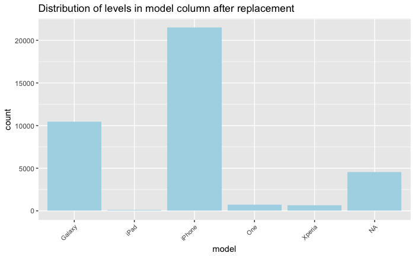

```r
ggplot(claims, aes(x = model)) + geom_bar(fill = "lightblue") + theme(axis.text.x = element_text(size  = 8, angle = 45, hjust = 1, vjust = 1)) + ggtitle("Distribution of levels in model column after replacement")
```

Cleaning the columns customer_number and contract_number

```r
levels(claims$customer_number) = gsub(".\"", NA, levels(claims$customer_number), fixed=TRUE)
levels(claims$customer_number) = gsub("+41765817477\"", NA, levels(claims$customer_number), fixed=TRUE)
levels(claims$customer_number) = gsub("079 269 88 64\"", NA, levels(claims$customer_number), fixed=TRUE)
claims$customer_number = as.character(claims$customer_number)
claims$customer_number[grepl("e", claims$customer_number)] = NA
claims$customer_number[grepl("E", claims$customer_number)] = NA
claims$customer_number[grepl("a", claims$customer_number)] = NA
claims$customer_number[grepl("a", claims$customer_number)] = NA
sum(is.na(claims$customer_number))*100/length(claims$customer_number)
```

```
[1] 2.177237
```

```r
claims$contract_number = as.character(claims$contract_number)
claims$contract_number[grepl("A", claims$contract_number)] = NA
claims$contract_number[grepl("a", claims$contract_number)] = NA
claims$contract_number[grepl("n", claims$contract_number)] = NA
claims$contract_number[grepl("u", claims$contract_number)] = NA
claims$contract_number[grepl("M", claims$contract_number)] = NA
claims$contract_number[grepl("P", claims$contract_number)] = NA
claims$contract_number[grepl("e", claims$contract_number)] = NA
claims$contract_number[grepl("r", claims$contract_number)] = NA
claims$contract_number[grepl("t", claims$contract_number)] = NA
claims$contract_number[grepl("s", claims$contract_number)] = NA
sum(is.na(claims$contract_number))*100/length(claims$contract_number)
```

```
[1] 2.179872
```

New table with only some of the columns of claims

```r
fraud_data = data.frame("claim_id"=claims$claim_id,"claim_number"=claims$claim_number,"customer_number"=claims$customer_number,"contract_number"=claims$contract_number,"claim_date"=claims$claim_date,"claim_type"=claims$claim_type,"device_type"=claims$device_type,"product_name"=claims$product_name,"make"=claims$make,"claim_device_make"=claims$claim_device_make,
"model"=claims$model,"claim_device_memory"=claims$claim_device_memory,"device_creation_date"=claims$device_creation_date,"city"=claims$city,"customer_language"=claims$customer_language,"reported_at"=claims$reported_at,"claim_created_by"=claims$claim_created_by,"what_happened"=claims$what_happened,"claim_scene"=claims$claim_scene,"claim_caused_by"=claims$claim_caused_by,"pictures_damage_required"=claims$Pictures.of.the.damaged.device.required.,"proof_purchase_required"=claims$Proof.of.purchase.required.,"police_report"=claims$Was.a.Police.report.filed.,"contract_status"=claims$contract_status,"settlement_reason"=claims$settlement_reason,"status_before_closed"=claims$status_before_closed,"claim_rejection_reason"=claims$claim_rejection_reason,"fraud_reason"=claims$fraud_reason)
```

Removing duplicated rows

```r
sum(duplicated(fraud_data))
```

```
[1] 477
```

```r
fraud_data = fraud_data[!duplicated(fraud_data),]
```

Summarizing the data

```r
str(fraud_data)
```

```
'data.frame':   37461 obs. of  28 variables:
 $ claim_id                : int  1291839 1323838 1331488 1335910 1364883 1419944 1608319 1637341 1692078 1803082 ...
 $ claim_number            : Factor w/ 37105 levels "SR10014","SR10035",..: 155 228 247 263 309 408 579 613 734 909 ...
 $ customer_number         : Factor w/ 27389 levels "1000000193","1000001032",..: 18779 20659 8261 3489 18165 8320 17531 10770 18594 16864 ...
 $ contract_number         : Factor w/ 30347 levels "6600","SC100098",..: 2472 11221 2257 6132 2394 9883 2578 10118 5738 11515 ...
 $ claim_date              : Factor w/ 886 levels "01.01.2015","01.01.2016",..: 843 10 211 323 10 763 240 473 620 NA ...
 $ claim_type              : Factor w/ 3 levels "ABUSED_CALL_CHARGE",..: 2 2 2 2 2 2 2 2 2 2 ...
 $ device_type             : Factor w/ 1 level "Mobiltelefon/Smartphone/PDA": 1 1 1 1 1 1 1 1 1 1 ...
 $ product_name            : Factor w/ 12 levels "Sunrise call protect",..: 6 6 6 6 6 2 6 6 8 6 ...
 $ make                    : Factor w/ 14 levels "Apple","Blackberry",..: 12 1 1 10 1 NA 6 1 1 12 ...
 $ claim_device_make       : Factor w/ 12 levels "Apple","Blackberry",..: 11 1 1 9 1 10 5 1 1 11 ...
 $ model                   : Factor w/ 5 levels "Galaxy","iPad",..: 5 3 3 NA 3 NA NA 3 3 5 ...
 $ claim_device_memory     : int  NA NA NA NA NA NA NA NA NA NA ...
 $ device_creation_date    : Factor w/ 531 levels "01.02.2016","01.02.2017",..: 262 262 262 262 262 262 262 262 262 262 ...
 $ city                    : Factor w/ 2972 levels "1004","1005",..: 2893 403 929 1521 738 762 2344 2501 1600 1278 ...
 $ customer_language       : Factor w/ 4 levels "de","en","fr",..: 1 1 4 4 1 3 1 1 3 3 ...
 $ reported_at             : Factor w/ 815 levels "01.01.2016","01.01.2017",..: 7 221 248 326 404 701 329 462 677 147 ...
 $ claim_created_by        : Factor w/ 2 levels "Agent","Customer": 1 1 1 1 1 1 1 1 1 1 ...
 $ what_happened           : Factor w/ 32526 levels "-","- Handy bei telefonieren, schaltet das Handy ab",..: 21126 8198 7255 16900 7182 16068 16157 14547 2681 30739 ...
 $ claim_scene             : Factor w/ 11004 levels " Im Treppenhaus",..: 6452 307 10072 4098 10072 10351 2206 10351 213 NA ...
 $ claim_caused_by         : Factor w/ 2 levels "3ed_party","Insured": 1 2 1 1 1 1 1 1 1 NA ...
 $ pictures_damage_required: Factor w/ 2 levels "No","Yes": 1 2 1 1 1 1 1 1 1 NA ...
 $ proof_purchase_required : Factor w/ 2 levels "No","Yes": 1 2 1 1 1 1 1 1 1 NA ...
 $ police_report           : Factor w/ 2 levels "No","Yes": NA NA NA NA NA NA NA NA NA NA ...
 $ contract_status         : Factor w/ 2 levels "ACTIVE","CANCELLED": 1 2 2 1 2 2 2 1 2 2 ...
 $ settlement_reason       : Factor w/ 13 levels "BREAK-IN_TO_PROPERTY",..: 5 NA 5 6 NA 5 5 6 NA NA ...
 $ status_before_closed    : Factor w/ 4 levels "AUTO_ABANDONED",..: 1 1 3 3 1 3 2 3 1 1 ...
 $ claim_rejection_reason  : Factor w/ 24 levels "Breakdown","Cannot provide insured incident",..: NA NA NA NA NA NA NA NA NA NA ...
 $ fraud_reason            : Factor w/ 6 levels "Declared theft of delivered device (stolen out of post box)",..: NA NA NA NA NA NA NA NA NA NA ...
```

## (4) A first “by hand” detection of frauds by creating a binary column “is_fraud” to be filled following some criteria.

```r
fraud_data$is_fraud = rep(0, nrow(fraud_data))
```

Distribution of nonNAs levels of fraud_reason

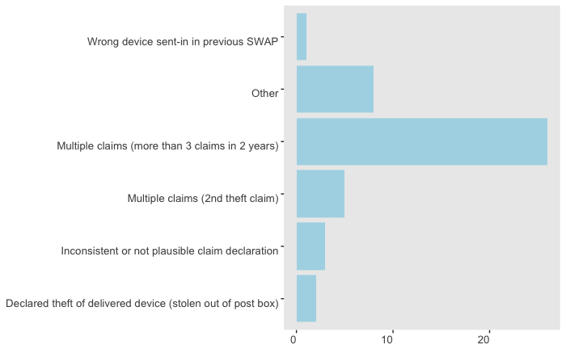

```r
nonnasFRfrauddata = fraud_data %>% filter(!is.na(fraud_reason))
ggplot(nonnasFRfrauddata, aes(x = fraud_reason)) + geom_bar(fill = "lightblue") + theme(axis.text.y = element_text(size  = 10, hjust = 1, vjust = 1)) + theme(axis.text.x = element_text(size  = 10, hjust = 1, vjust = 1)) + rremove("grid") + rremove("xlab") + coord_flip() + rremove("xlab") + rremove("ylab")
```

Distribution of nonNAs levels of claim_rejection_reason

```r
levels(fraud_data$claim_rejection_reason)
```

```
 [1] "Breakdown"                                         "Cannot provide insured incident"                   "Claim Freeze"
 [4] "Claim Limit (Comfort)"                             "Cosmetic Damage"                                   "Damage caused by Virus / Software error"
 [7] "Deliberate Damage / Unlawful Act"                  "Device Modified from Manufacturer's Specification" "Device not insured"
[10] "Fraud"                                             "Gross Negligence"                                  "Handset in Manufacturer warranty"
[13] "Incomplete Information"                            "Left in Public Place (if Loss)"                    "Misrepresentation / Inconsistency"
[16] "no cover: loss"                                    "No Reasonable Precaution"                          "Not reported to Insurer in Time"
[19] "Other party liable"                                "Previously Unsuccessful Claim"                     "Theft from Unlocked Vehicle (if Theft)"
[22] "Theft not reported to Police in Time (if Theft)"   "Unauthorised Person"                               "Wear and Tear"
```

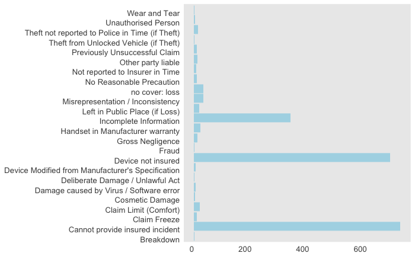

```r
nonnasCRRfrauddata = fraud_data %>% filter(!is.na(claim_rejection_reason))
ggplot(nonnasCRRfrauddata, aes(x = claim_rejection_reason)) + geom_bar(fill = "lightblue") + theme(axis.text.y = element_text(size  = 10, hjust = 1, vjust = 1)) + theme(axis.text.x = element_text(size  = 10, hjust = 1, vjust = 1)) + rremove("grid") + coord_flip() + rremove("x.ticks")+ rremove("y.ticks") + rremove("xlab") + rremove("ylab")
```

Distribution of levels of status_before_closed

```r
levels(fraud_data$status_before_closed)
```

```
[1] "AUTO_ABANDONED"     "CANCELLED"          "FULFILLED_RESOLVED" "RESOLVED_DENIED"
```

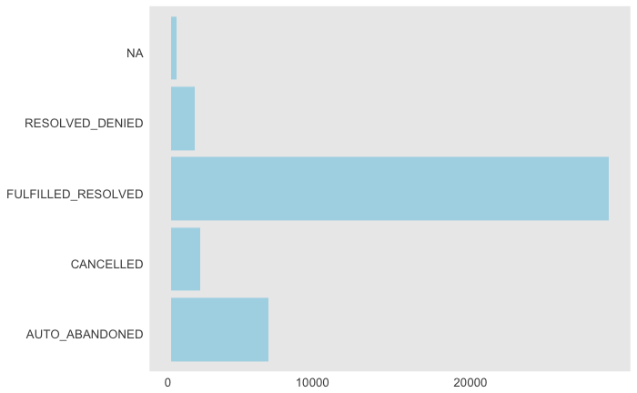

```r
ggplot(fraud_data, aes(x = status_before_closed)) + geom_bar(fill = "lightblue") + theme(axis.text.y = element_text(size  = 10, hjust = 1, vjust = 1)) + theme(axis.text.x = element_text(size  = 10, hjust = 1, vjust = 1)) + rremove("ylab") + rremove("grid") + rremove("xlab") + coord_flip() + rremove("x.ticks")+ rremove("y.ticks")
```

Distribution of levels of claim_type

```r
levels(fraud_data$claim_type)
```

```
[1] "ABUSED_CALL_CHARGE" "DAMAGED"            "STOLEN"
```

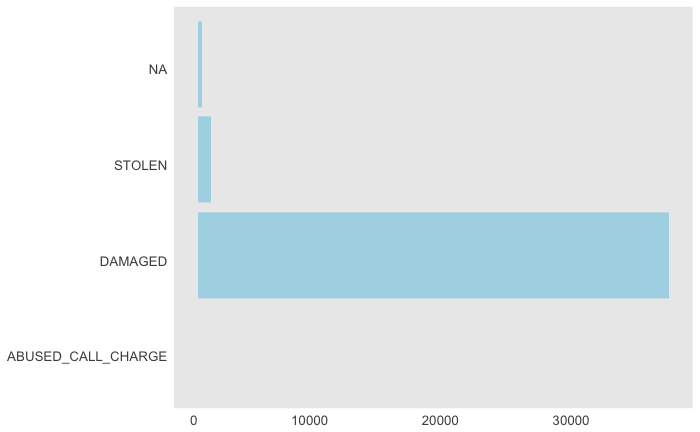

```r
ggplot(fraud_data, aes(x = claim_type)) + geom_bar(fill = "lightblue") + theme(axis.text.y = element_text(size  = 10, hjust = 1, vjust = 1)) + theme(axis.text.x = element_text(size  = 10, hjust = 1, vjust = 1)) + rremove("ylab") + rremove("grid") + rremove("xlab") + coord_flip() + rremove("x.ticks") + rremove("y.ticks")
```

Criterion 1: all the rows that have entries in fraud_reason are fraud

```r
fraud_data$is_fraud = ifelse(!is.na(fraud_data$fraud_reason), 1, 0)
```

```r
fraud_data$claim_rejection_reason = as.character(fraud_data$claim_rejection_reason)
fraud_data$is_fraud[fraud_data$claim_rejection_reason=="Theft not reported to Police in Time (if Theft)"]=1
fraud_data$is_fraud[fraud_data$claim_rejection_reason=="Fraud"]=1
fraud_data$is_fraud[fraud_data$claim_rejection_reason=="Incomplete Information"]=1
fraud_data$is_fraud[fraud_data$claim_rejection_reason=="Misrepresentation / Inconsistency"]=1
fraud_data$is_fraud[fraud_data$claim_rejection_reason=="Theft not reported to Police in Time (if Theft)"]=1
```

Criterion 3: if the entry of status_before_closed is “auto_abandoned” or “resolved_denied” and claim_rejection_reason has an entry then it is a fraud

```r
fraud_data$status_before_closed = as.character(fraud_data$status_before_closed)
fraud_data$is_fraud[fraud_data$status_before_closed=="AUTO_ABANDONED"&!is.na(fraud_data$claim_rejection_reason)]=1
fraud_data$is_fraud[fraud_data$status_before_closed=="RESOLVED_DENIED"&!is.na(fraud_data$claim_rejection_reason)]=1
```

Criterion 4: if the entry of claim_type is “stolen” and the entry of police_report column is “No” then it is a fraud

```r
fraud_data$claim_type = as.character(fraud_data$claim_type)
fraud_data$police_report = as.character(fraud_data$police_report)
fraud_data$is_fraud[fraud_data$claim_type=="STOLEN"&fraud_data$police_report=="No"]=1
```

Final fraud_data.

```r
fraud_data$claim_type = factor(fraud_data$claim_type)
fraud_data$police_report = factor(fraud_data$police_report)
fraud_data$status_before_closed = factor(fraud_data$status_before_closed)
fraud_data$claim_rejection_reason = factor(fraud_data$claim_rejection_reason)
fraud_data$is_fraud = factor(fraud_data$is_fraud)
fraud_data$fraud_reason = as.character(fraud_data$fraud_reason)
fraud_data$fraud_reason[is.na(fraud_data$fraud_reason)] = "unknown"
fraud_data$police_report = as.character(fraud_data$police_report)
fraud_data$police_report[is.na(fraud_data$police_report)] = "unknown"
fraud_data$claim_rejection_reason = as.character(fraud_data$claim_rejection_reason)
fraud_data$claim_rejection_reason[is.na(fraud_data$claim_rejection_reason)] = "unknown"
fraud_data$police_report = factor(fraud_data$police_report)
fraud_data$fraud_reason = factor(fraud_data$fraud_reason)
fraud_data$claim_rejection_reason = factor(fraud_data$claim_rejection_reason)
str(fraud_data)
```

```
'data.frame':   37461 obs. of  29 variables:
 $ claim_id                : int  1291839 1323838 1331488 1335910 1364883 1419944 1608319 1637341 1692078 1803082 ...
 $ claim_number            : Factor w/ 37105 levels "SR10014","SR10035",..: 155 228 247 263 309 408 579 613 734 909 ...
 $ customer_number         : Factor w/ 27389 levels "1000000193","1000001032",..: 18779 20659 8261 3489 18165 8320 17531 10770 18594 16864 ...
 $ contract_number         : Factor w/ 30347 levels "6600","SC100098",..: 2472 11221 2257 6132 2394 9883 2578 10118 5738 11515 ...
 $ claim_date              : Factor w/ 886 levels "01.01.2015","01.01.2016",..: 843 10 211 323 10 763 240 473 620 NA ...
 $ claim_type              : Factor w/ 3 levels "ABUSED_CALL_CHARGE",..: 2 2 2 2 2 2 2 2 2 2 ...
 $ device_type             : Factor w/ 1 level "Mobiltelefon/Smartphone/PDA": 1 1 1 1 1 1 1 1 1 1 ...
 $ product_name            : Factor w/ 12 levels "Sunrise call protect",..: 6 6 6 6 6 2 6 6 8 6 ...
 $ make                    : Factor w/ 14 levels "Apple","Blackberry",..: 12 1 1 10 1 NA 6 1 1 12 ...
 $ claim_device_make       : Factor w/ 12 levels "Apple","Blackberry",..: 11 1 1 9 1 10 5 1 1 11 ...
 $ model                   : Factor w/ 5 levels "Galaxy","iPad",..: 5 3 3 NA 3 NA NA 3 3 5 ...
 $ claim_device_memory     : int  NA NA NA NA NA NA NA NA NA NA ...
 $ device_creation_date    : Factor w/ 531 levels "01.02.2016","01.02.2017",..: 262 262 262 262 262 262 262 262 262 262 ...
 $ city                    : Factor w/ 2972 levels "1004","1005",..: 2893 403 929 1521 738 762 2344 2501 1600 1278 ...
 $ customer_language       : Factor w/ 4 levels "de","en","fr",..: 1 1 4 4 1 3 1 1 3 3 ...
 $ reported_at             : Factor w/ 815 levels "01.01.2016","01.01.2017",..: 7 221 248 326 404 701 329 462 677 147 ...
 $ claim_created_by        : Factor w/ 2 levels "Agent","Customer": 1 1 1 1 1 1 1 1 1 1 ...
 $ what_happened           : Factor w/ 32526 levels "-","- Handy bei telefonieren, schaltet das Handy ab",..: 21126 8198 7255 16900 7182 16068 16157 14547 2681 30739 ...
 $ claim_scene             : Factor w/ 11004 levels " Im Treppenhaus",..: 6452 307 10072 4098 10072 10351 2206 10351 213 NA ...
 $ claim_caused_by         : Factor w/ 2 levels "3ed_party","Insured": 1 2 1 1 1 1 1 1 1 NA ...
 $ pictures_damage_required: Factor w/ 2 levels "No","Yes": 1 2 1 1 1 1 1 1 1 NA ...
 $ proof_purchase_required : Factor w/ 2 levels "No","Yes": 1 2 1 1 1 1 1 1 1 NA ...
 $ police_report           : Factor w/ 3 levels "No","unknown",..: 2 2 2 2 2 2 2 2 2 2 ...
 $ contract_status         : Factor w/ 2 levels "ACTIVE","CANCELLED": 1 2 2 1 2 2 2 1 2 2 ...
 $ settlement_reason       : Factor w/ 13 levels "BREAK-IN_TO_PROPERTY",..: 5 NA 5 6 NA 5 5 6 NA NA ...
 $ status_before_closed    : Factor w/ 4 levels "AUTO_ABANDONED",..: 1 1 3 3 1 3 2 3 1 1 ...
 $ claim_rejection_reason  : Factor w/ 25 levels "Breakdown","Cannot provide insured incident",..: 24 24 24 24 24 24 24 24 24 24 ...
 $ fraud_reason            : Factor w/ 7 levels "Declared theft of delivered device (stolen out of post box)",..: 6 6 6 6 6 6 6 6 6 6 ...
 $ is_fraud                : Factor w/ 2 levels "0","1": 1 1 1 1 1 1 1 1 1 1 ...
```

The number of frauds in the fraud_data set increased from 0.1186146 percent to 4.7836417 percent after the “by hand” detection of frauds.

## (5) Can machine learning find and characterize other frauds?

The by hand detection of frauds led us to discover 4.7836417 percent of frauds. Since the business department of the insurance is expecting to double the percentage of frauds, we want to find out whether we can double this percentage using some machine learning algorithms.

We will start using a decision tree algorithm by splitting the data set into a training and a test set.

The algorithm of decision trees works as follows. We assume that we have a set T of training samples. Let the possible classes be denoted as ${C_1, C_2, ..., C_k}$. There are three possibilities depending on the content of the set $T$.  
1. $T$ contains one or more samples, all belonging to a single class $C_j$. The decision tree for T is a leaf identifying class $C_j$.  
2. $T$ contains no samples. The decision tree is again a leaf but the class to be associated with the leaf must be determined from information other than T, e.g. the most frequent class as the parent of the given node.  
3. $T$ contains samples that belong to a mixture of classes. It must be refined into subsets of samples that are closer to being a single-class collection of samples. Based on the value of a single attribute, an appropriate test that has a certain number of mutually exclusive outcomes ${O_1, O_2, ..., O_n}$ is chosen. $T$ is partitioned into subsets $T_1, T_2,...,T_n$, where $T_i$ contains all the samples in $T$ that have outcome $O_i$ of the chosen test.  
The decision tree for $T$ consists of a decision node identifying the test and one branch for each possible outcome. The successive division of the set of training samples proceeds until all the subsets consist of sample belonging to a single class. The choice of test at a given node has to minimize the number of test that will allow a sample to be classified.

Training phase: training data (with paired input/output) are fed to the model to train it.  
Test phase: test data are used to estimate the accuracy of the selected approach.  
The function createDataPartition can be used to create splits of the data in such a way that, if the y argument to this function is a factor, the random sampling occurs within each class and should preserve the overall class distribution of the data.  
The 70% of the data will go to the training set.

```r
set.seed(123)
trainIndex = createDataPartition(fraud_data$is_fraud, p = .7, list = FALSE)
# list = FALSE avoids returns the data as a list, times = 1 creates only one split
imbal_fraud_train = fraud_data[trainIndex,]
imbal_fraud_test = fraud_data[-trainIndex,]
cat("Percentage of frauds in imbal_fraud_train","\n")
```

```
Percentage of frauds in imbal_fraud_train
```

```r
sum(imbal_fraud_train$is_fraud==1)*100/(nrow(imbal_fraud_train))
```

```
[1] 4.785692
```

```r
cat("\n","Percentage of frauds in imbal_fraud_test","\n")
```

```
 Percentage of frauds in imbal_fraud_test
```

```r
sum(imbal_fraud_test$is_fraud==1)*100/(nrow(imbal_fraud_test))
```

```
[1] 4.778856
```

```r
cat("\n","Proportion table for frauds in imbal_fraud_train","\n")
```

```
 Proportion table for frauds in imbal_fraud_train
```

```r
prop.table(table(imbal_fraud_train$is_fraud))
```

```
         0          1
0.95214308 0.04785692
```

```r
cat("\n", "Proportion table for frauds in imbal_fraud_test","\n")
```

```
 Proportion table for frauds in imbal_fraud_test
```

```r
prop.table(table(imbal_fraud_test$is_fraud))
```

```
         0          1
0.95221144 0.04778856
```

We use the decision tree algorithm on the imbalanced training data set and check the performance of its the prediction on the test set by measuring recall, the area under the ROC curve and the false positive rate.  
We are interested in maximizing “recall” = R = TP/(TP+FN) = TP/(# of real positives), also called “true positive rate”, because we want to have zero false negative, i.e. we want to be able to detect all the frauds. We are also interested in the “false positive rate”, also called inverse recall, because we want to find also “new frauds”, i.e. frauds not discovered by the “by hand” process, using this machine learning algorithm.

For our decision tree algorithm we will have a “true positive rate” = TPR = TP/(TP+FN) = TP/(# of real positives) and a “false positive rate” = FPR = FP/(TN+FP) = FP/(# of real negatives), namely a point in the so called ROC space. By drawing a line from (0,0) to this point and from there to (1,1) in the ROC space we find the ROC curve. In general (but not in our case), we get the best performance, i.e. TPR=1 (FN=0) and FPR=0 (FP=0), when the area under this roc curve is 1, and we get the worst performance when the area is 0.5. Note that an AUC around 0.5 means that the curve is close to the 45 degrees diagonal of the ROC space and so that the true positive rate is almost equal to the false positive rate, i.e. that we are simply randomly guessing a class for each observation.

```r
treeimb = rpart(is_fraud ~ ., data = imbal_fraud_train )
pred.treeimb = predict(treeimb, newdata = imbal_fraud_test)
cat("\n","recall:", "\n", "\n")
```

```
 recall:
```

```r
print(accuracy.meas(imbal_fraud_test$is_fraud, pred.treeimb[,2])$recall)
```

```
[1] 0.9385475
```

```r
cat("\n")
```

```
Area under the curve (AUC): 0.965
```

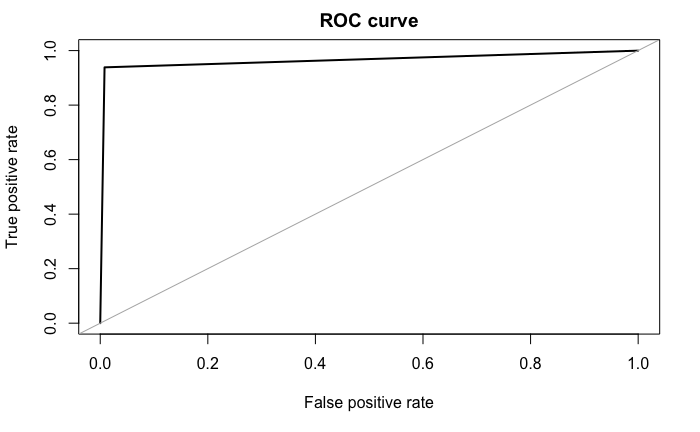

```r
print(roc.curve(imbal_fraud_test$is_fraud, pred.treeimb[,2], plotit = TRUE))
```

```r
cat("\n","confusion matrix","\n")
```

```
 confusion matrix
```

```r
tbimb = table(pred.treeimb[,2], imbal_fraud_test$is_fraud)

print(tbimb)
```

```
        0     1
  0 10614    33
  1    86   504
```

```r
cat("\n","false positive percentage","\n", "\n")
```

```
 false positive percentage
```

```r
print((tbimb[2,1]/sum(tbimb))*100)
```

```
[1] 0.7653288
```

In this case the recall is really high, since recall: 0.9385475 but the false positive percentage is really low. Maybe this is done to the fact that decision tree are prone to over fitting and so that we are closely following the particular split in training and testing data. Then it is better to use a k-folds cross validation procedure. Indeed, by default the createDataPartition function creates a single partition in training and test set of the original data. If we divide the fraud data into 5 folds and then we do 5 steps, in each of which we fix one of the folds as test set and the other 4 as training set, we can check how the recall, the area under the ROC curve and the false positive percentage of the decision tree algorithm vary depending on the particular folds chosen as train and test.

```
 recall:

[1] 0.7988669

Area under the curve (AUC): 0.899

 confusion matrix


                       0    1
  0                 7128   71
  0.999305555555556   12  282

 false positive percentage

[1] 0.1601495

 recall:

[1] 0.9495549
```

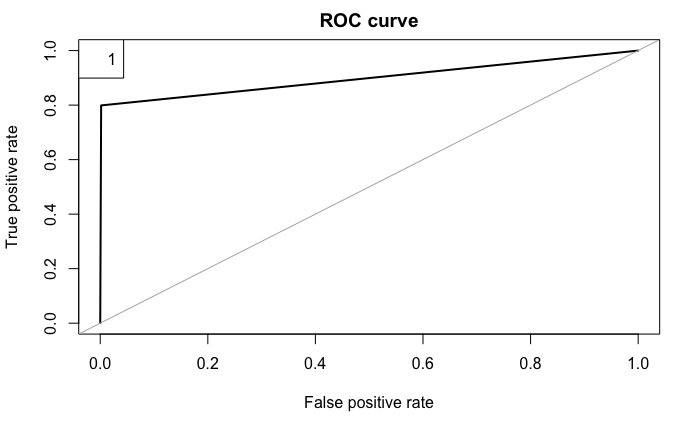

```
Area under the curve (AUC): 0.972

 confusion matrix


                       0    1
  0                 7109   17
  0.999313186813187   46  320

 false positive percentage

[1] 0.6139883

 recall:

[1] 0.9296188
```

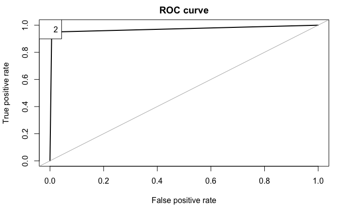

```
Area under the curve (AUC): 0.961

 confusion matrix


                      0    1
  0                7099   24
  0.99931129476584   52  317

 false positive percentage

[1] 0.6940737

 recall:

[1] 0.933687
```

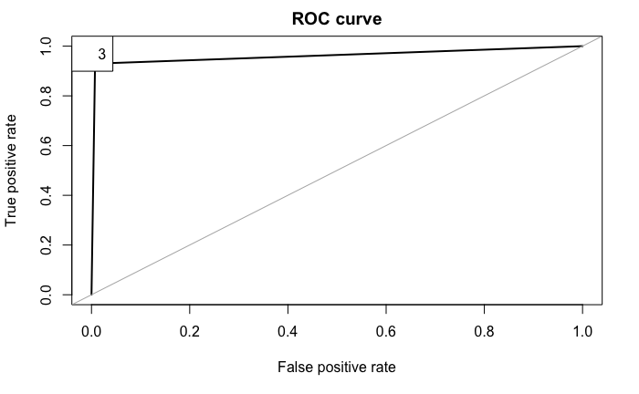

```
Area under the curve (AUC): 0.962

 confusion matrix


                       0    1
  0                 7043   25
  0.999293785310734   72  352

 false positive percentage

[1] 0.9610251

 recall:

[1] 0.9375
```

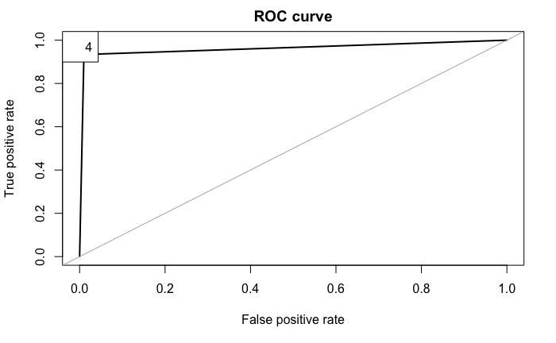

```
Area under the curve (AUC): 0.965

 confusion matrix


       0    1
  0 7061   24
  1   47  360

 false positive percentage

[1] 0.6273358
```

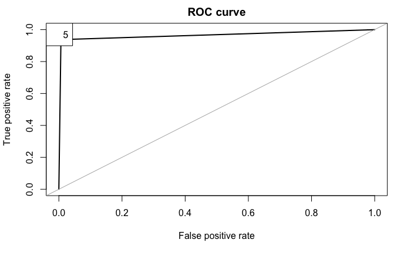

```r
#Randomly shuffle the data
fraud_data = fraud_data[sample(nrow(fraud_data)),]
#Create 5 equally size folds
folds = cut(seq(1,nrow(fraud_data)),breaks=5,labels=FALSE)
#Perform 5 fold cross validation
aucimb = c()
fppimb = c()
rimb = c()
for(i in 1:5){

  #Segementing my data by fold using the which() function

  testIndexes = which(folds==i,arr.ind=TRUE)

  testData = fraud_data[testIndexes, ]

  trainData = fraud_data[-testIndexes, ]

  treeimb2 = rpart(is_fraud ~ ., data = trainData)

  pred.treeimb2 = predict(treeimb2, newdata = testData)

  cat("\n","recall:", "\n", "\n")

  print(accuracy.meas(testData$is_fraud, pred.treeimb2[,2])$recall)

  cat("\n")

  print(roc.curve(testData$is_fraud, pred.treeimb2[,2], plotit = TRUE))

  cat("\n","confusion matrix","\n","\n")

  tbimb = table(pred.treeimb2[,2], testData$is_fraud)

  print(tbimb)

  legend("topleft", c("fold"), i)

  cat("\n","false positive percentage","\n", "\n")

  print((tbimb[2,1]/sum(tbimb))*100)

  rimb = c(rimb, accuracy.meas(testData$is_fraud, pred.treeimb2[,2])$recall)

  aucimb = c(aucimb,roc.curve(testData$is_fraud, pred.treeimb2[,2], plotit = FALSE)$auc)

  fppimb = c(fppimb,(tbimb[2,1]/sum(tbimb))*100)
}
```

```r
cat("\n","average recall", mean(rimb), "\n")
```

```
 average recall 0.9098455
```

```r
cat("\n", "average AUC", mean(aucimb), "\n")
```

```
 average AUC 0.9517114
```

```r
cat("\n", "average false positive percentage", mean(fppimb))
```

```
 average false positive percentage 0.6113145
```

The results that we obtain by averaging recall, AUC and false positive percentage over 5 folds cross validation are pretty close to the previous one. So it does not seem that the first tree was over fitting the training set that it was using to learn. But maybe the false positive percentage is so low even averaging it among 5 folds with cross validation because our training sets are highly imbalanced and so the classifier is biased towards majority class, i.e. towards the non-frauds.  
We can use sampling methods in order to modify an imbalanced data set into a balanced distribution by altering the size of original data set and by providing the same proportion of balance.  
To create a balanced data set we will try two ways. First we will use the function ovun.sample of the ROSE package with method = “over”, that will over sample with replacement the minority class, namely the class of frauds. Then we will use the function ovun.sample of the ROSE package with method = “under”, that will under sample without replacement the majority class, namely the class of non-frauds. In both cases we will obtain a new data set with around 50% of fraud cases and 50% of non-fraud cases.

```r
fraud_balanced_over = ovun.sample(is_fraud ~ ., data = fraud_data, method = "over", p=.5)$data
# p .5 means half fraud and half non-frauds
cat("Proportion table for frauds in the data set balanced with method over","\n")
```

```
Proportion table for frauds in the data set balanced with method over
```

```r
prop.table(table(fraud_balanced_over$is_fraud))
```

```
        0         1
0.5013243 0.4986757
```

```r
cat("\n","number of observations in the data set obtained with method over","\n","\n")
```

```
 number of observations in the data set obtained with method over
```

```r
nrow(fraud_balanced_over)
```

```
[1] 33603
```

```r
fraud_balanced_under = ovun.sample(is_fraud ~ ., data = fraud_data,method = "under", p=.5)$data
cat("\n","Proportion table for frauds in the training data set balanced with method under","\n")
```

```
 Proportion table for frauds in the training data set balanced with method under
```

```r
prop.table(table(fraud_balanced_under$is_fraud))
```

```
        0         1
0.5225806 0.4774194
```

```r
cat("\n","number of observations in training data set obtained with method under","\n", "\n")
```

```
 number of observations in training data set obtained with method under
```

```r
nrow(fraud_balanced_under)
```

```
[1] 155
```

The number of observations in the data set obtained with under sampling is really low, so it will led to under fitting.